# notebook_task2

```python
import pandas as pd
import matplotlib.pyplot as plt
import seaborn as sns
import datetime
from scipy import stats
import numpy as np
```

### Stores Doing Trial: 77, 86, 88

```python
df = pd.read_csv('QVI_clean.scv')
```

```python
df.head(4)
```

|  | Unnamed: 0 | LYLTY_CARD_NBR | LIFESTAGE | PREMIUM_CUSTOMER | DATE | STORE_NBR | TXN_ID | PROD_NBR | PROD_NAME | PROD_QTY | TOT_SALES | YEAR | MONTH | DAY | SIZE_IN_GRAMS | BRAND | TOTAL_SPENT |
| --- | --- | --- | --- | --- | --- | --- | --- | --- | --- | --- | --- | --- | --- | --- | --- | --- | --- |
| 0 | 0 | 47142.0 | MIDAGE SINGLES/COUPLES | Budget | 2018-07-01 | 47.0 | 42540.0 | 14.0 | Smiths Crnkle Chip Orgnl Big Bag 380g | 2.0 | 11.8 | 2018 | July | Sunday | 380.0 | Smiths | 11.80 |
| 1 | 1 | 55073.0 | MIDAGE SINGLES/COUPLES | Budget | 2018-07-01 | 55.0 | 48884.0 | 99.0 | Pringles Sthrn FriedChicken 134g | 2.0 | 7.4 | 2018 | July | Sunday | 134.0 | Pringles | 58.25 |
| 2 | 2 | 55073.0 | MIDAGE SINGLES/COUPLES | Budget | 2018-07-01 | 55.0 | 48884.0 | 91.0 | CCs Tasty Cheese 175g | 2.0 | 4.2 | 2018 | July | Sunday | 175.0 | CCs | 58.25 |
| 3 | 3 | 58351.0 | MIDAGE SINGLES/COUPLES | Budget | 2018-07-01 | 58.0 | 54374.0 | 102.0 | Kettle Mozzarella Basil & Pesto 175g | 2.0 | 10.8 | 2018 | July | Sunday | 175.0 | Kettle | 10.80 |

## Remove Stores With Too Little Transactional Data Across the Year

We are interested in stores that have data throughout the entire year. So lets filter out the stores which staisfy this

```python
df.groupby(by='STORE_NBR')['DATE'].nunique().sort_values(ascending=False).head(5)
```

```
STORE_NBR
133.0    362
152.0    362
226.0    362
213.0    362
259.0    362
Name: DATE, dtype: int64
```

```python
# Stores with missing months

stores_with_missing_months = df.groupby(by='STORE_NBR')['MONTH'].nunique()
filtered_stores = stores_with_missing_months[stores_with_missing_months < 10].index

print(f'Stores with fewer than 12 months:: {filtered_stores}')
```

```
Stores with fewer than 12 months:: Index([], dtype='float64', name='STORE_NBR')
```

```python
# Drop these
df = df[~df['STORE_NBR'].isin(filtered_stores)]
```

```python
# There will still be stores with only a few transaction p/month.
# We can filter these by removing sotres who have.
stores_with_low_monthly_trans = df.groupby(by=['STORE_NBR', 'MONTH'])['DATE'].nunique()
filtered_stores = stores_with_low_monthly_trans[stores_with_low_monthly_trans < 15]
# Get the unique FIRST index.
filtered_stores = filtered_stores.index.get_level_values(0).unique()

# Drop these
df = df[~df['STORE_NBR'].isin(filtered_stores)]
```

```python
# How many stores are left?
df['STORE_NBR'].nunique()
```

```
235
```

```python
# Lets make sure we have the stores doing the trial: 77, 86, 88
df[(df['STORE_NBR'] == 78) | (df['STORE_NBR'] == 88) | (df['STORE_NBR'] == 86)]
```

|  | Unnamed: 0 | LYLTY_CARD_NBR | LIFESTAGE | PREMIUM_CUSTOMER | DATE | STORE_NBR | TXN_ID | PROD_NBR | PROD_NAME | PROD_QTY | TOT_SALES | YEAR | MONTH | DAY | SIZE_IN_GRAMS | BRAND | TOTAL_SPENT |
| --- | --- | --- | --- | --- | --- | --- | --- | --- | --- | --- | --- | --- | --- | --- | --- | --- | --- |
| 29 | 29 | 78115.0 | MIDAGE SINGLES/COUPLES | Mainstream | 2018-07-01 | 78.0 | 76138.0 | 87.0 | Infuzions BBQ Rib Prawn Crackers 110g | 2.0 | 7.6 | 2018 | July | Sunday | 110 | Infuzions | 46.8 |
| 31 | 31 | 88076.0 | MIDAGE SINGLES/COUPLES | Mainstream | 2018-07-01 | 88.0 | 86585.0 | 9.0 | Kettle Tortilla ChpsBtroot&Ricotta 150g | 2.0 | 9.2 | 2018 | July | Sunday | 150 | Kettle | 24.0 |
| 32 | 32 | 88140.0 | MIDAGE SINGLES/COUPLES | Mainstream | 2018-07-01 | 88.0 | 86914.0 | 25.0 | Pringles SourCream Onion 134g | 2.0 | 7.4 | 2018 | July | Sunday | 134 | Pringles | 36.0 |
| 115 | 115 | 86082.0 | OLDER FAMILIES | Budget | 2018-07-01 | 86.0 | 84643.0 | 3.0 | Kettle Sensations Camembert & Fig 150g | 2.0 | 9.2 | 2018 | July | Sunday | 150 | Kettle | 34.2 |
| 160 | 160 | 88155.0 | OLDER FAMILIES | Mainstream | 2018-07-01 | 88.0 | 86995.0 | 68.0 | Pringles Chicken Salt Crips 134g | 2.0 | 7.4 | 2018 | July | Sunday | 134 | Pringles | 54.0 |
| ... | ... | ... | ... | ... | ... | ... | ... | ... | ... | ... | ... | ... | ... | ... | ... | ... | ... |
| 249452 | 249452 | 78129.0 | YOUNG FAMILIES | Budget | 2019-06-30 | 78.0 | 76215.0 | 58.0 | Red Rock Deli Chikn&Garlic Aioli 150g | 2.0 | 5.4 | 2019 | June | Sunday | 150 | RRD | 59.6 |
| 249453 | 249453 | 78176.0 | YOUNG FAMILIES | Budget | 2019-06-30 | 78.0 | 76482.0 | 61.0 | Smiths Crinkle Cut Chips Chicken 170g | 2.0 | 5.8 | 2019 | June | Sunday | 170 | Smiths | 62.6 |
| 249496 | 249496 | 86198.0 | YOUNG FAMILIES | Mainstream | 2019-06-30 | 86.0 | 85372.0 | 58.0 | Red Rock Deli Chikn&Garlic Aioli 150g | 2.0 | 5.4 | 2019 | June | Sunday | 150 | RRD | 53.4 |
| 249594 | 249594 | 86045.0 | YOUNG SINGLES/COUPLES | Mainstream | 2019-06-30 | 86.0 | 84426.0 | 98.0 | NCC Sour Cream & Garden Chives 175g | 2.0 | 6.0 | 2019 | June | Sunday | 175 | NCC | 88.4 |
| 249595 | 249595 | 88342.0 | YOUNG SINGLES/COUPLES | Mainstream | 2019-06-30 | 88.0 | 87918.0 | 23.0 | Cheezels Cheese 330g | 2.0 | 11.4 | 2019 | June | Sunday | 330 | Cheezels | 58.2 |

4524 rows × 17 columns

## Explore Monthly Trends for the Trial Stores

```python
# Seems like none of the data types save after exporting and importing my csv so I have to do it again here
df.dropna(axis=0, inplace=True)

month_order = ['January', 'February', 'March', 'April', 'May', 'June', 'July',
               'August', 'September', 'October', 'November', 'December']
day_order = ['Monday', 'Tuesday', 'Wednesday', 'Thursday', 'Friday', 'Saturday', 'Sunday']
df['MONTH'] = pd.Categorical(df['MONTH'], categories=month_order, ordered=True)
df['DAY'] = pd.Categorical(df['DAY'], categories=day_order, ordered=True)
df['SIZE_IN_GRAMS'] = df['PROD_NAME'].str.extract(r'(\d+)[gG]').astype('int')
df['LIFESTAGE'] = df['LIFESTAGE'].astype('category')
df['PREMIUM_CUSTOMER'] = pd.Categorical(df['PREMIUM_CUSTOMER'], categories=['Budget', 'Mainstream', 'Premium'  ], ordered=True)
df['DATE'] = pd.to_datetime(df['DATE'])
```

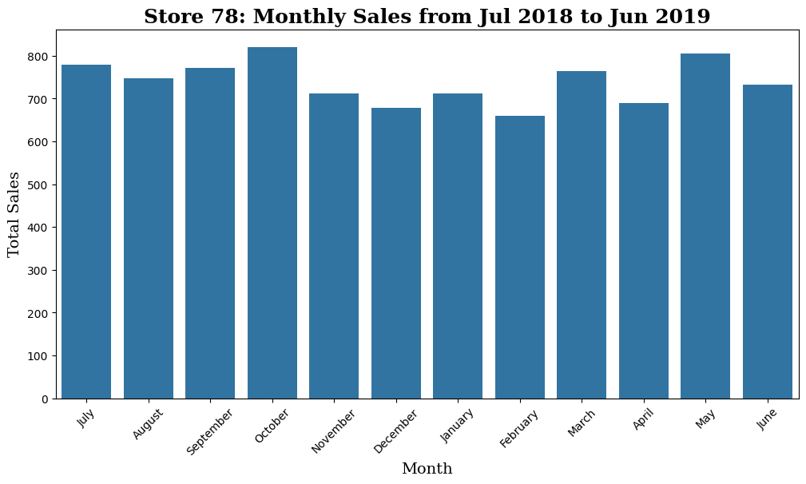

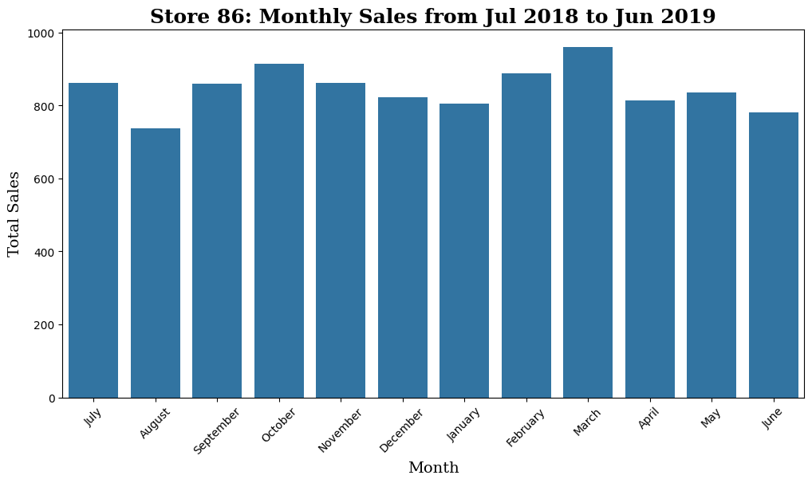

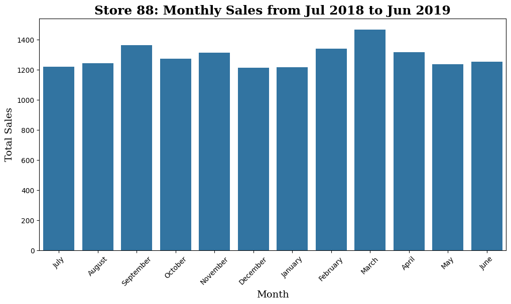

```python
month_order = ['July', 'August', 'September', 'October', 'November', 'December',
               'January', 'February', 'March', 'April', 'May', 'June']

monthly_sales = df[df['STORE_NBR'] == 78].groupby('MONTH', observed=False)['TOT_SALES'].sum()

plt.figure(figsize=(12,6))
sns.barplot(x=monthly_sales.index, y=monthly_sales, order=month_order)

plt.title('Store 78: Monthly Sales from Jul 2018 to Jun 2019', fontsize=18, fontweight='bold', fontfamily='serif')
plt.xlabel('Month', fontsize=14, fontfamily='serif')
plt.ylabel('Total Sales', fontsize=14, fontfamily='serif')
plt.xticks(rotation=45)  # Rotate x-axis labels for better visibility
plt.show()
plt.close()


monthly_sales = df[df['STORE_NBR'] == 86].groupby('MONTH', observed=False)['TOT_SALES'].sum()
# monthly_sales = monthly_sales[month_order]

plt.figure(figsize=(12,6))
sns.barplot(x=monthly_sales.index, y=monthly_sales, order=month_order)

plt.title('Store 86: Monthly Sales from Jul 2018 to Jun 2019', fontsize=18, fontweight='bold', fontfamily='serif')
plt.xlabel('Month', fontsize=14, fontfamily='serif')
plt.ylabel('Total Sales', fontsize=14, fontfamily='serif')
plt.xticks(rotation=45)  # Rotate x-axis labels for better visibility
plt.show()
plt.close()


monthly_sales = df[df['STORE_NBR'] == 88].groupby('MONTH', observed=False)['TOT_SALES'].sum()
# monthly_sales = monthly_sales[month_order]

plt.figure(figsize=(12,6))
sns.barplot(x=monthly_sales.index, y=monthly_sales, order=month_order)

plt.title('Store 88: Monthly Sales from Jul 2018 to Jun 2019', fontsize=18, fontweight='bold', fontfamily='serif')
plt.xlabel('Month', fontsize=14, fontfamily='serif')
plt.ylabel('Total Sales', fontsize=14, fontfamily='serif')
plt.xticks(rotation=45)  # Rotate x-axis labels for better visibility
plt.show()
```

## Calculate Total Revenue p/Month, # of Customers p/Month, and Avg Transactions p/Customer p/Month.

```python
# Filter data for the period of interest (e.g., July 2018 - June 2019)
start_date = '2018-07-01'
end_date = '2019-01-31'
filtered_df = df[(df['DATE'] >= start_date) & (df['DATE'] <= end_date)]


# Get TOTAL SALES per store per month
monthly_sales = filtered_df.groupby(['STORE_NBR', pd.Grouper(key='DATE', freq='ME')])['TOT_SALES'].sum().unstack(fill_value=0)
monthly_sales = monthly_sales.T

# NO. of CUSTOMERS P/MONTH.
monthly_customers = filtered_df.groupby(['STORE_NBR', pd.Grouper(key='DATE', freq='ME')])['LYLTY_CARD_NBR'].nunique().unstack(fill_value=0)
monthly_customers = monthly_customers.T

# Average number of transactions per customer per month.
monthly_transactions = filtered_df.groupby(['STORE_NBR', pd.Grouper(key='DATE', freq='ME')]).size().unstack(fill_value=0)  # Total transactions (rows) per store per month
monthly_customers = filtered_df.groupby(['STORE_NBR', pd.Grouper(key='DATE', freq='ME')])['LYLTY_CARD_NBR'].nunique().unstack(fill_value=0)  # Number of unique customers per store per month
avg_transactions_per_customer = monthly_transactions / monthly_customers  # Calculate the average number of transactions per customer per month
avg_transactions_per_customer = avg_transactions_per_customer.T
```

## Define function to find best Pearsons Correlation between test store and control stores

```python
# Stores
stores = monthly_sales.columns
# Transpose this again for functions
monthly_customers = monthly_customers.T
#Define trial stores
trial_stores = [77, 86, 88]
```

```python
# Create a function that minimises
def min_corr(trial_store, stores):
    # Highest correlation
    correlations = {}  # {trial_store: {control_store: (a, b, c)}}
    for j in trial_store:
        correlations[j] = {}  # Initialize inner dictionary for each trial store
        for i in stores:
            if i not in trial_store:
                a = monthly_sales.loc[:, j].corr(monthly_sales.loc[:, i])
                b = monthly_customers.loc[:, j].corr(monthly_customers.loc[:, i])
                c = avg_transactions_per_customer.loc[:, j].corr(avg_transactions_per_customer.loc[:, i])
                correlations[j][i] = (a, b, c)
            else:
                pass
       # Compute min correlations per control store
        min_scores = {store: min(corrs) for store, corrs in correlations[j].items()}

        #  # Compute highest average
        # min_scores = {store: np.median(corrs) for store, corrs in correlations[j].items()}

        best_store = max(min_scores, key=min_scores.get)
        best_corrs = correlations[j][best_store]
        print(f'Best control store for trial store {j} is store {best_store} with correlations: {best_corrs}')
    return correlations  # Return for later use
```

```python
# Find control stores with biggest correlation
correlations = min_corr(trial_store=trial_stores, stores=stores)
```

```
Best control store for trial store 77 is store 84.0 with correlations: (np.float64(0.6211394206078755), np.float64(0.8086899604018802), np.float64(0.6622933061287001))
Best control store for trial store 86 is store 176.0 with correlations: (np.float64(0.6294791954372881), np.float64(0.7558204875430532), np.float64(0.7900571473834768))
Best control store for trial store 88 is store 145.0 with correlations: (np.float64(0.5119102374038524), np.float64(0.46630617823260456), np.float64(0.5467904521576857))
```

## Define function to find lowest standardised metric between test stores and control stores

```python
# Create a function to calculate the standardized metric
def standardized_metric(trial_store, stores):
    # Store for tracking the absolute differences
    performance_diff = {}  # {trial_sotre: {store: (sales_diff, customer_diff, transactions_diff)}}

    # Iterate over the trial stores
    for j in trial_store:
        performance_diff[j] = {}  # Initialize inner dictionary for each trial store
        for i in stores:
            if i not in trial_store:
                # Calculate absolute differences for each metric
                sales_diff = np.abs(monthly_sales.loc[:, j] - monthly_sales.loc[:, i])
                customer_diff = np.abs(monthly_customers.loc[:, j] - monthly_customers.loc[:, i])
                transactions_diff = np.abs(avg_transactions_per_customer.loc[:, j] - avg_transactions_per_customer.loc[:, i])

                # Standardize the differences by dividing by the trial store's std deviation
                sales_std = monthly_sales.loc[:, j].std()
                customer_std = monthly_customers.loc[:, j].std()
                transactions_std = avg_transactions_per_customer.loc[:, j].std()

                standardized_sales_diff = sales_diff / sales_std if sales_std != 0 else sales_diff
                standardized_customer_diff = customer_diff / customer_std if customer_std != 0 else customer_diff
                standardized_transactions_diff = transactions_diff / transactions_std if transactions_std != 0 else transactions_diff

                '''
                # LESS ROBUST
                # Calculate the total standardized difference (could sum or average them)
                total_diff = standardized_sales_diff + standardized_customer_diff + standardized_transactions_diff
                performance_diff[j][i] = total_diff.mean()  # Store the mean of the total difference
                '''

                # Calculate the total standardized difference
                performance_diff[j][i] = np.median([
                    standardized_sales_diff.median(),
                        standardized_customer_diff.median(),
                            standardized_transactions_diff.median()
                                ])

        # Now, find the control store with the minimum standardized difference
        best_control_store = min(performance_diff[j], key=performance_diff[j].get)
        best_diff = performance_diff[j][best_control_store]

        print(f'For trial store {j}: Best control store is {best_control_store} with standardized difference: {best_diff:.3f}')
        # return(performance_diff)

    return performance_diff  # for later use
```

```python
performance_use = standardized_metric(trial_store=trial_stores, stores=stores)
```

```
For trial store 77: Best control store is 233.0 with standardized difference: 0.436
For trial store 86: Best control store is 219.0 with standardized difference: 0.505
For trial store 88: Best control store is 237.0 with standardized difference: 0.697
```

## Create function to find control store based on the highest correlation and lowest standardised metric

```python
def decide_best_control_store(trial_store, stores, correlations, standardized_differences, w1=0.4, w2=0.6): # Chose weight to emphasize more importance on similar volumes.
    best_control = None
    best_score = -float('inf')  # Set an initial best score

    for store in stores:
        if store != trial_store:
            # Get correlation and standardized difference for current store
            corr = min(correlations[trial_store].get(store, (0,0,0)))
            std_diff = standardized_differences[trial_store].get(store, float('inf'))

            # Calculate weighted score
            score = w1 * corr + w2 * (1 / std_diff if std_diff != 0 else float('inf'))  # Avoid divide by zero

            # Update best control store based on score
            if score > best_score:
                best_score = score
                best_control = store

    return best_control, best_score
```

```python
# Example usage for each trial store
for trial_store in trial_stores:
    best_control, best_score = decide_best_control_store(trial_store, stores, correlations, performance_use)
    print(f"For trial store {trial_store}, the best control store is {best_control} with a score of {best_score:.3f}")
```

```
For trial store 77, the best control store is 233.0 with a score of 1.256
For trial store 86, the best control store is 219.0 with a score of 1.193
For trial store 88, the best control store is 237.0 with a score of 0.823
```

The stores with the a combination of the highest correlation and lowest standardised metric for our metrics

- Total revenue p/month.
- No. of customers per month.
- Avg transaction p/customer p/month.

are:

- For trial store 77, the best control store is 233
- For trial store 86, the best control store is 219
- For trial store 88, the best control store is 237

## Let's do some visualisations of month-to-month metrics of the test and control scores

### Total monthly sales.

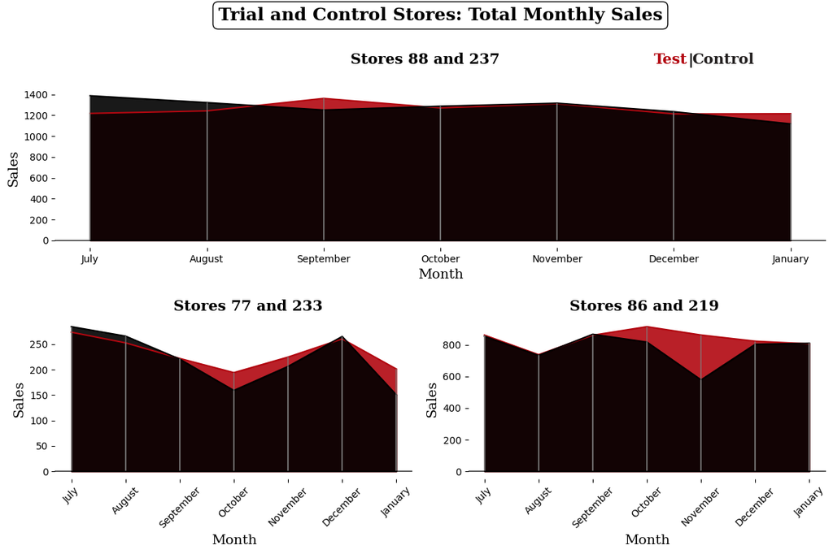

```python
# sns.lineplot(y=monthly_sales.loc[:,77], x=monthly_sales.index)
color = ["#b20710", "#221f1f"]

fig, ax = plt.subplots(2, 2, figsize=(12, 8))

# Plot
ax[1,0].plot(monthly_sales.index.month_name(), monthly_sales.loc[:,77], color=color[0], label='Test Store')
ax[1,0].fill_between(monthly_sales.index.month_name(), 0, monthly_sales.loc[:,77], color=color[0], alpha=0.9)
ax[1,0].plot(monthly_sales.index.month_name(), monthly_sales.loc[:,233], color='black', label='Control Store')
ax[1,0].fill_between(monthly_sales.index.month_name(), 0, monthly_sales.loc[:,233], color='black', alpha=0.9)
# Axis labels
ax[1,0].set_xlabel('Month', fontsize=14, fontfamily='serif')
ax[1,0].set_ylabel('Sales', fontsize=14, fontfamily='serif')
# Fix x-ticks
ax[1,0].set_xticks(monthly_sales.index.month_name())
ax[1,0].set_xticklabels(monthly_sales.index.month_name(), rotation=45)
for date in monthly_sales.index:
    ax[1,0].vlines(x=date.month_name(), ymin=0, ymax=monthly_sales.loc[date, 77], colors='grey', alpha=0.6)
    ax[1,0].vlines(x=date.month_name(), ymin=0, ymax=monthly_sales.loc[date, 233], colors='grey', alpha=0.6)

# Plot
ax[1,1].plot(monthly_sales.index.month_name(), monthly_sales.loc[:,86], color=color[0], label='Test Store')
ax[1,1].fill_between(monthly_sales.index.month_name(), 0, monthly_sales.loc[:,86], color=color[0], alpha=0.9)
ax[1,1].plot(monthly_sales.index.month_name(), monthly_sales.loc[:,219], color='black', label='Control Store')
ax[1,1].fill_between(monthly_sales.index.month_name(), 0, monthly_sales.loc[:,219], color='black', alpha=0.9)
# Axis labels
ax[1,1].set_xlabel('Month', fontsize=14, fontfamily='serif')
ax[1,1].set_ylabel('Sales', fontsize=14, fontfamily='serif')
# Fix x-ticks
ax[1,1].set_xticks(monthly_sales.index.month_name())
ax[1,1].set_xticklabels(monthly_sales.index.month_name(), rotation=45)
for date in monthly_sales.index:
    ax[1,1].vlines(x=date.month_name(), ymin=0, ymax=monthly_sales.loc[date, 86], colors='grey', alpha=0.6)
    ax[1,1].vlines(x=date.month_name(), ymin=0, ymax=monthly_sales.loc[date, 219], colors='grey', alpha=0.6)

# # Add gridlines
# for i in range(2):
#     ax[1,i].grid(axis='y', color='gray', alpha=.7)
# Horizontal line on x-axis
for i in range(2):
    ax[1,i].yaxis.tick_left()
    ax[1,i].axhline(y = 0, color = 'black', linewidth = 1.3, alpha = .7)
# Remove spines
for i in range(2):
    for s in ['top', 'right','bottom','left']:
        ax[1,i].spines[s].set_visible(False)




# Remove unnecessary subplots
fig.delaxes(ax[0, 1])  # Remove empty subplot
fig.delaxes(ax[0, 0])  # Remove empty subplot

# Add a big top plot
ax_top = fig.add_subplot(2, 1, 1)
# Plot
ax_top.plot(monthly_sales.index.month_name(), monthly_sales.loc[:,88], color=color[0], label='Test Store')
ax_top.fill_between(monthly_sales.index.month_name(), 0, monthly_sales.loc[:,88], color=color[0], alpha=0.9)
ax_top.plot(monthly_sales.index.month_name(), monthly_sales.loc[:,237], color='black', label='Test Store')
ax_top.fill_between(monthly_sales.index.month_name(), 0, monthly_sales.loc[:,237], color='black', alpha=0.9)
for date in monthly_sales.index:
    ax_top.vlines(x=date.month_name(), ymin=0, ymax=monthly_sales.loc[date, 88], colors='grey', alpha=0.6)
    ax_top.vlines(x=date.month_name(), ymin=0, ymax=monthly_sales.loc[date, 237], colors='grey', alpha=0.6)

# Plot title
ax_top.set_title('Trial and Control Stores: Total Monthly Sales', pad=70, fontsize=18, fontfamily='serif', fontweight='bold',
                 bbox=dict(facecolor='white', edgecolor='black', boxstyle='round,pad=0.3'))
# Axis labels
ax_top.set_xlabel('Month', fontsize=14, fontfamily='serif')
ax_top.set_ylabel('Sales', fontsize=14, fontfamily='serif')
# Fix x-ticks
ax_top.set_xticks(monthly_sales.index.month_name())
ax_top.set_xticklabels(monthly_sales.index.month_name(), rotation=0)
# # Add gridlines
# ax_top.grid(axis='y', color='gray', alpha=.7)
# Horizontal line on x-axis
ax_top.axhline(y = 0, color = 'black', linewidth = 1.3, alpha = .7)

# Remove spines
for s in ['top', 'right','bottom','left']:
    ax_top.spines[s].set_visible(False)


# Add titles
fig.text(.42, .88, 'Stores 88 and 237', fontsize=15, fontweight='bold', fontfamily='serif')
fig.text(.21, .44, 'Stores 77 and 233', fontsize=15, fontfamily='serif', fontweight='bold')
fig.text(.68, .44, 'Stores 86 and 219', fontsize=15, fontfamily='serif', fontweight='bold')
fig.text(0.78,0.88,"Test", fontweight="bold", fontfamily='serif', fontsize=15, color='#b20710')
fig.text(0.82,0.88,"|", fontweight="bold", fontfamily='serif', fontsize=15, color='black')
fig.text(0.825,0.88,"Control", fontweight="bold", fontfamily='serif', fontsize=15, color='#221f1f')


plt.tight_layout()
plt.subplots_adjust(hspace=.45)
```

### No. of Monthly Customers

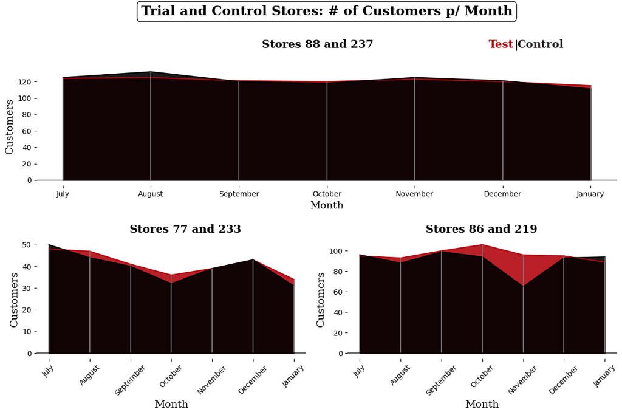

```python
color = ["#b20710", "#221f1f"]

fig, ax = plt.subplots(2, 2, figsize=(12, 8))

# Plot
ax[1,0].plot(monthly_customers.index.month_name(), monthly_customers.loc[:,77], color=color[0], label='Test Store')
ax[1,0].fill_between(monthly_customers.index.month_name(), 0, monthly_customers.loc[:,77], color=color[0], alpha=0.9)
ax[1,0].plot(monthly_customers.index.month_name(), monthly_customers.loc[:,233], color='black', label='Control Store')
ax[1,0].fill_between(monthly_customers.index.month_name(), 0, monthly_customers.loc[:,233], color='black', alpha=0.9)
# Axis labels
ax[1,0].set_xlabel('Month', fontsize=14, fontfamily='serif')
ax[1,0].set_ylabel('Customers', fontsize=14, fontfamily='serif')
# Fix x-ticks
ax[1,0].set_xticks(monthly_customers.index.month_name())
ax[1,0].set_xticklabels(monthly_customers.index.month_name(), rotation=45)
for date in monthly_sales.index:
    ax[1,0].vlines(x=date.month_name(), ymin=0, ymax=monthly_customers.loc[date, 77], colors='grey', alpha=0.6)
    ax[1,0].vlines(x=date.month_name(), ymin=0, ymax=monthly_customers.loc[date, 233], colors='grey', alpha=0.6)


# Plot
ax[1,1].plot(monthly_customers.index.month_name(), monthly_customers.loc[:,86], color=color[0], label='Test Store')
ax[1,1].fill_between(monthly_customers.index.month_name(), 0, monthly_customers.loc[:,86], color=color[0], alpha=0.9)
ax[1,1].plot(monthly_customers.index.month_name(), monthly_customers.loc[:,219], color='black', label='Control Store')
ax[1,1].fill_between(monthly_customers.index.month_name(), 0, monthly_customers.loc[:,219], color='black', alpha=0.9)
# Axis labels
ax[1,1].set_xlabel('Month', fontsize=14, fontfamily='serif')
ax[1,1].set_ylabel('Customers', fontsize=14, fontfamily='serif')
# Fix x-ticks
ax[1,1].set_xticks(monthly_customers.index.month_name())
ax[1,1].set_xticklabels(monthly_customers.index.month_name(), rotation=45)
for date in monthly_sales.index:
    ax[1,1].vlines(x=date.month_name(), ymin=0, ymax=monthly_customers.loc[date, 86], colors='grey', alpha=0.6)
    ax[1,1].vlines(x=date.month_name(), ymin=0, ymax=monthly_customers.loc[date, 219], colors='grey', alpha=0.6)

# # Add gridlines
# for i in range(2):
#     ax[1,i].grid(axis='y', color='gray', alpha=.7)
# Horizontal line on x-axis
for i in range(2):
    ax[1,i].yaxis.tick_left()
    ax[1,i].axhline(y = 0, color = 'black', linewidth = 1.3, alpha = .7)
# Remove spines
for i in range(2):
    for s in ['top', 'right','bottom','left']:
        ax[1,i].spines[s].set_visible(False)



# Remove unnecessary subplots
fig.delaxes(ax[0, 1])  # Remove empty subplot
fig.delaxes(ax[0, 0])  # Remove empty subplot

# Add a big top plot
ax_top = fig.add_subplot(2, 1, 1)
# Plot
ax_top.plot(monthly_customers.index.month_name(), monthly_customers.loc[:,88], color=color[0], label='Test Store')
ax_top.fill_between(monthly_customers.index.month_name(), 0, monthly_customers.loc[:,88], color=color[0], alpha=0.9)
ax_top.plot(monthly_customers.index.month_name(), monthly_customers.loc[:,237], color='black', label='Test Store')
ax_top.fill_between(monthly_customers.index.month_name(), 0, monthly_customers.loc[:,237], color='black', alpha=0.9)
for date in monthly_sales.index:
    ax_top.vlines(x=date.month_name(), ymin=0, ymax=monthly_customers.loc[date, 88], colors='grey', alpha=0.6)
    ax_top.vlines(x=date.month_name(), ymin=0, ymax=monthly_customers.loc[date, 237], colors='grey', alpha=0.6)

# Plot title
ax_top.set_title('Trial and Control Stores: # of Customers p/ Month', pad=70, fontsize=18, fontfamily='serif', fontweight='bold',
                 bbox=dict(facecolor='white', edgecolor='black', boxstyle='round,pad=0.3'))
# Axis labels
ax_top.set_xlabel('Month', fontsize=14, fontfamily='serif')
ax_top.set_ylabel('Customers', fontsize=14, fontfamily='serif')
# Fix x-ticks
ax_top.set_xticks(monthly_customers.index.month_name())
ax_top.set_xticklabels(monthly_customers.index.month_name(), rotation=0)
# # Add gridlines
# ax_top.grid(axis='y', color='gray', alpha=.7)
# Horizontal line on x-axis
ax_top.axhline(y = 0, color = 'black', linewidth = 1.3, alpha = .7)

# Remove spines
for s in ['top', 'right','bottom','left']:
    ax_top.spines[s].set_visible(False)


# Add titles
fig.text(.42, .88, 'Stores 88 and 237', fontsize=15, fontweight='bold', fontfamily='serif')
fig.text(.21, .44, 'Stores 77 and 233', fontsize=15, fontfamily='serif', fontweight='bold')
fig.text(.68, .44, 'Stores 86 and 219', fontsize=15, fontfamily='serif', fontweight='bold')
fig.text(0.78,0.88,"Test", fontweight="bold", fontfamily='serif', fontsize=15, color='#b20710')
fig.text(0.82,0.88,"|", fontweight="bold", fontfamily='serif', fontsize=15, color='black')
fig.text(0.825,0.88,"Control", fontweight="bold", fontfamily='serif', fontsize=15, color='#221f1f')


plt.tight_layout()
plt.subplots_adjust(hspace=.45)
```

### Average Transactions p/ Customer

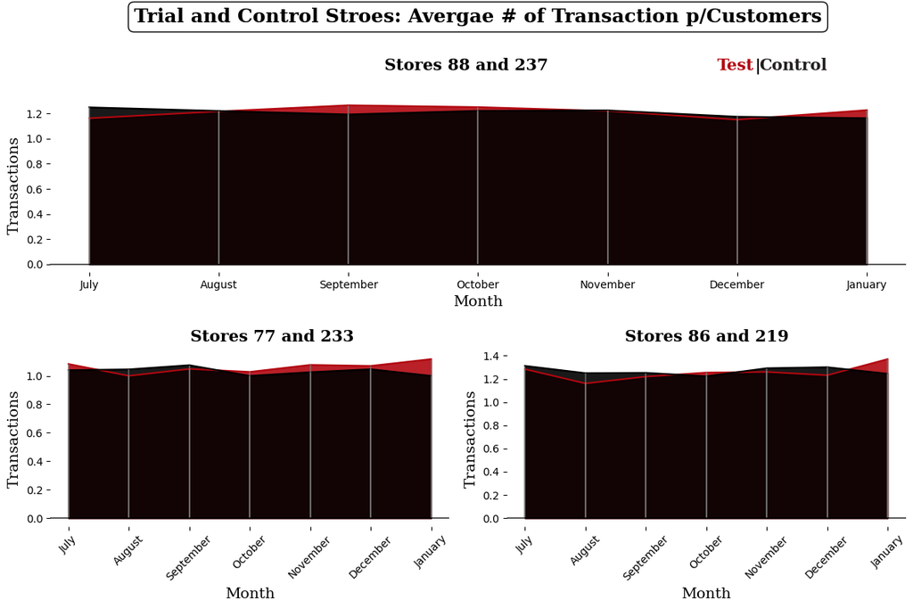

```python
color = ["#b20710", "#221f1f"]

fig, ax = plt.subplots(2, 2, figsize=(12, 8))

# Plot
ax[1,0].plot(avg_transactions_per_customer.index.month_name(), avg_transactions_per_customer.loc[:,77], color=color[0], label='Test Store')
ax[1,0].fill_between(avg_transactions_per_customer.index.month_name(), 0, avg_transactions_per_customer.loc[:,77], color=color[0], alpha=0.9)
ax[1,0].plot(avg_transactions_per_customer.index.month_name(), avg_transactions_per_customer.loc[:,233], color='black', label='Control Store')
ax[1,0].fill_between(avg_transactions_per_customer.index.month_name(), 0, avg_transactions_per_customer.loc[:,233], color='black', alpha=0.9)
# Axis labels
ax[1,0].set_xlabel('Month', fontsize=14, fontfamily='serif')
ax[1,0].set_ylabel('Transactions', fontsize=14, fontfamily='serif')
# Fix x-ticks
ax[1,0].set_xticks(avg_transactions_per_customer.index.month_name())
ax[1,0].set_xticklabels(avg_transactions_per_customer.index.month_name(), rotation=45)
for date in monthly_sales.index:
    ax[1,0].vlines(x=date.month_name(), ymin=0, ymax=avg_transactions_per_customer.loc[date, 77], colors='grey', alpha=0.6)
    ax[1,0].vlines(x=date.month_name(), ymin=0, ymax=avg_transactions_per_customer.loc[date, 233], colors='grey', alpha=0.6)

# Plot
ax[1,1].plot(avg_transactions_per_customer.index.month_name(), avg_transactions_per_customer.loc[:,86], color=color[0], label='Test Store')
ax[1,1].fill_between(avg_transactions_per_customer.index.month_name(), 0, avg_transactions_per_customer.loc[:,86], color=color[0], alpha=0.9)
ax[1,1].plot(avg_transactions_per_customer.index.month_name(), avg_transactions_per_customer.loc[:,219], color='black', label='Control Store')
ax[1,1].fill_between(avg_transactions_per_customer.index.month_name(), 0, avg_transactions_per_customer.loc[:,219], color='black', alpha=0.9)
# Axis labels
ax[1,1].set_xlabel('Month', fontsize=14, fontfamily='serif')
ax[1,1].set_ylabel('Transactions', fontsize=14, fontfamily='serif')
# Fix x-ticks
ax[1,1].set_xticks(avg_transactions_per_customer.index.month_name())
ax[1,1].set_xticklabels(avg_transactions_per_customer.index.month_name(), rotation=45)
for date in monthly_sales.index:
    ax[1,1].vlines(x=date.month_name(), ymin=0, ymax=avg_transactions_per_customer.loc[date, 86], colors='grey', alpha=0.6)
    ax[1,1].vlines(x=date.month_name(), ymin=0, ymax=avg_transactions_per_customer.loc[date, 219], colors='grey', alpha=0.6)

# Add gridlines
# for i in range(2):
#     ax[1,i].grid(axis='y', color='gray', alpha=.7)
# Horizontal line on x-axis
for i in range(2):
    ax[1,i].yaxis.tick_left()
    ax[1,i].axhline(y = 0, color = 'black', linewidth = 1.3, alpha = .7)
# Remove spines
for i in range(2):
    for s in ['top', 'right','bottom','left']:
        ax[1,i].spines[s].set_visible(False)




# Remove unnecessary subplots
fig.delaxes(ax[0, 1])  # Remove empty subplot
fig.delaxes(ax[0, 0])  # Remove empty subplot

# Add a big top plot
ax_top = fig.add_subplot(2, 1, 1)
# Plot
ax_top.plot(avg_transactions_per_customer.index.month_name(), avg_transactions_per_customer.loc[:,88], color=color[0], label='Test Store')
ax_top.fill_between(avg_transactions_per_customer.index.month_name(), 0, avg_transactions_per_customer.loc[:,88], color=color[0], alpha=0.9)
ax_top.plot(avg_transactions_per_customer.index.month_name(), avg_transactions_per_customer.loc[:,237], color='black', label='Test Store')
ax_top.fill_between(avg_transactions_per_customer.index.month_name(), 0, avg_transactions_per_customer.loc[:,237], color='black', alpha=0.9)
for date in monthly_sales.index:
    ax_top.vlines(x=date.month_name(), ymin=0, ymax=avg_transactions_per_customer.loc[date, 88], colors='grey', alpha=0.6)
    ax_top.vlines(x=date.month_name(), ymin=0, ymax=avg_transactions_per_customer.loc[date, 237], colors='grey', alpha=0.6)


# Plot title
ax_top.set_title('Trial and Control Stroes: Avergae # of Transaction p/Customers', pad=70, fontsize=18, fontfamily='serif', fontweight='bold',
                 bbox=dict(facecolor='white', edgecolor='black', boxstyle='round,pad=0.3'))
# Axis labels
ax_top.set_xlabel('Month', fontsize=14, fontfamily='serif')
ax_top.set_ylabel('Transactions', fontsize=14, fontfamily='serif')
# Fix x-ticks
ax_top.set_xticks(avg_transactions_per_customer.index.month_name())
ax_top.set_xticklabels(avg_transactions_per_customer.index.month_name(), rotation=0)
# # Add gridlines
# ax_top.grid(axis='y', color='gray', alpha=.7)
# Horizontal line on x-axis
ax_top.axhline(y = 0, color = 'black', linewidth = 1.3, alpha = .7)

# Remove spines
for s in ['top', 'right','bottom','left']:
    ax_top.spines[s].set_visible(False)


# Add titles
fig.text(.42, .88, 'Stores 88 and 237', fontsize=15, fontweight='bold', fontfamily='serif')
fig.text(.21, .44, 'Stores 77 and 233', fontsize=15, fontfamily='serif', fontweight='bold')
fig.text(.68, .44, 'Stores 86 and 219', fontsize=15, fontfamily='serif', fontweight='bold')
fig.text(0.78,0.88,"Test", fontweight="bold", fontfamily='serif', fontsize=15, color='#b20710')
fig.text(0.82,0.88,"|", fontweight="bold", fontfamily='serif', fontsize=15, color='black')
fig.text(0.825,0.88,"Control", fontweight="bold", fontfamily='serif', fontsize=15, color='#221f1f')


plt.tight_layout()
plt.subplots_adjust(hspace=.45)
```

## Check the trial period total sales

```python
start_date = '2018-07-01'
end_date = '2019-05-31'

# Filter the trial date
filtered_df = df[(df['DATE'] >= start_date) & (df['DATE'] <= end_date)]
# Get TOTAL SALES per store per month
monthly_sales = filtered_df.groupby(['STORE_NBR', pd.Grouper(key='DATE', freq='ME')])['TOT_SALES'].sum().unstack(fill_value=0)
monthly_sales = monthly_sales.T

# NO. of CUSTOMERS P/MONTH.
monthly_customers = filtered_df.groupby(['STORE_NBR', pd.Grouper(key='DATE', freq='ME')])['LYLTY_CARD_NBR'].nunique().unstack(fill_value=0)
monthly_customers = monthly_customers.T

# Average number of transactions per customer per month.
monthly_transactions = filtered_df.groupby(['STORE_NBR', pd.Grouper(key='DATE', freq='ME')]).size().unstack(fill_value=0)  # Total transactions (rows) per store per month
monthly_customers = filtered_df.groupby(['STORE_NBR', pd.Grouper(key='DATE', freq='ME')])['LYLTY_CARD_NBR'].nunique().unstack(fill_value=0)  # Number of unique customers per store per month
avg_transactions_per_customer = monthly_transactions / monthly_customers  # Calculate the average number of transactions per customer per month
avg_transactions_per_customer = avg_transactions_per_customer.T


# NO. of CUSTOMERS P/MONTH.
monthly_customers = filtered_df.groupby(['STORE_NBR', pd.Grouper(key='DATE', freq='ME')])['LYLTY_CARD_NBR'].nunique().unstack(fill_value=0)
monthly_customers = monthly_customers.T
```

### Total Monthly Sales

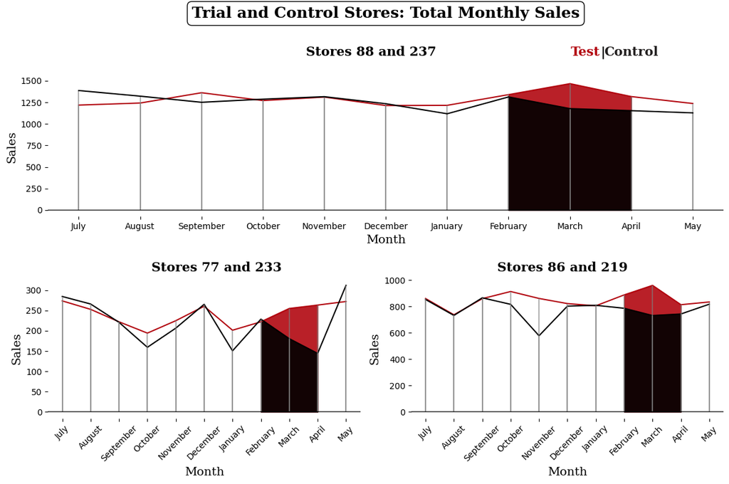

```python
color = ["#b20710", "#221f1f"]

fig, ax = plt.subplots(2, 2, figsize=(12, 8))

# Plot
ax[1,0].plot(monthly_sales.index.month_name(), monthly_sales.loc[:,77], color=color[0], label='Test Store')
# Fill only between start and end date
ax[1,0].fill_between(monthly_sales.index.month_name(), monthly_sales.loc[:,77], 0, where=(monthly_sales.index>'2019-01-31') & (monthly_sales.index<='2019-04-30'), color=color[0], alpha=0.9)
ax[1,0].plot(monthly_sales.index.month_name(), monthly_sales.loc[:,233], color='black', label='Control Store')
ax[1,0].fill_between(monthly_sales.index.month_name(), monthly_sales.loc[:,233], 0, where=(monthly_sales.index>'2019-01-31') & (monthly_sales.index<='2019-04-30'), color='black', alpha=0.9)
# Axis labels
ax[1,0].set_xlabel('Month', fontsize=14, fontfamily='serif')
ax[1,0].set_ylabel('Sales', fontsize=14, fontfamily='serif')
# Fix x-ticks
ax[1,0].set_xticks(monthly_sales.index.month_name())
ax[1,0].set_xticklabels(monthly_sales.index.month_name(), rotation=45)

for date in monthly_sales.index:
    ax[1,0].vlines(x=date.month_name(), ymin=0, ymax=monthly_sales.loc[date, 77], colors='grey', alpha=0.6)
    ax[1,0].vlines(x=date.month_name(), ymin=0, ymax=monthly_sales.loc[date, 233], colors='grey', alpha=0.6)


# Plot
ax[1,1].plot(monthly_sales.index.month_name(), monthly_sales.loc[:,86], color=color[0], label='Test Store')
ax[1,1].fill_between(monthly_sales.index.month_name(), monthly_sales.loc[:,86], 0, where=(monthly_sales.index>'2019-01-31') & (monthly_sales.index<='2019-04-30'), color=color[0], alpha=0.9)
ax[1,1].plot(monthly_sales.index.month_name(), monthly_sales.loc[:,219], color='black', label='Control Store')
ax[1,1].fill_between(monthly_sales.index.month_name(), monthly_sales.loc[:,219], 0, where=(monthly_sales.index>'2019-01-31') & (monthly_sales.index<='2019-04-30'), color='black', alpha=0.9)
# Axis labels
ax[1,1].set_xlabel('Month', fontsize=14, fontfamily='serif')
ax[1,1].set_ylabel('Sales', fontsize=14, fontfamily='serif')
# Fix x-ticks
ax[1,1].set_xticks(monthly_sales.index.month_name())
ax[1,1].set_xticklabels(monthly_sales.index.month_name(), rotation=45)


# Add gridlines
# for i in range(2):
    # ax[1,i].grid(axis='y', color='gray', alpha=.7)

for date in monthly_sales.index:
    ax[1,1].vlines(x=date.month_name(), ymin=0, ymax=monthly_sales.loc[date, 86], colors='grey', alpha=0.6)
    ax[1,1].vlines(x=date.month_name(), ymin=0, ymax=monthly_sales.loc[date, 219], colors='grey', alpha=0.6)
# Horizontal line on x-axis
for i in range(2):
    ax[1,i].yaxis.tick_left()
    ax[1,i].axhline(y = 0, color = 'black', linewidth = 1.3, alpha = .7)
# Remove spines
for i in range(2):
    for s in ['top', 'right','bottom','left']:
        ax[1,i].spines[s].set_visible(False)




# Remove unnecessary subplots
fig.delaxes(ax[0, 1])  # Remove empty subplot
fig.delaxes(ax[0, 0])  # Remove empty subplot

# Add a big top plot
ax_top = fig.add_subplot(2, 1, 1)
# Plot
ax_top.plot(monthly_sales.index.month_name(), monthly_sales.loc[:,88], color=color[0], label='Test Store')
ax_top.fill_between(monthly_sales.index.month_name(), monthly_sales.loc[:,88], 0, where=(monthly_sales.index>'2019-01-31') & (monthly_sales.index<='2019-04-30'), color=color[0], alpha=0.9)
for date in monthly_sales.index:
    ax_top.vlines(x=date.month_name(), ymin=0, ymax=monthly_sales.loc[date, 88], colors='grey', alpha=0.6)
    ax_top.vlines(x=date.month_name(), ymin=0, ymax=monthly_sales.loc[date, 237], colors='grey', alpha=0.6)
ax_top.plot(monthly_sales.index.month_name(), monthly_sales.loc[:,237], color='black', label='Test Store')
ax_top.fill_between(monthly_sales.index.month_name(), monthly_sales.loc[:,237], 0, where=(monthly_sales.index>'2019-01-31') & (monthly_sales.index<='2019-04-30'), color='black', alpha=0.9)


# Plot title
ax_top.set_title('Trial and Control Stores: Total Monthly Sales', pad=70, fontsize=18, fontfamily='serif', fontweight='bold',
                 bbox=dict(facecolor='white', edgecolor='black', boxstyle='round,pad=0.3'))
# Axis labels
ax_top.set_xlabel('Month', fontsize=14, fontfamily='serif')
ax_top.set_ylabel('Sales', fontsize=14, fontfamily='serif')
# Fix x-ticks
ax_top.set_xticks(monthly_sales.index.month_name())
ax_top.set_xticklabels(monthly_sales.index.month_name(), rotation=0)
# Add gridlines
# ax_top.grid(axis='y', color='gray', alpha=.7)
# Horizontal line on x-axis
ax_top.axhline(y = 0, color = 'black', linewidth = 1.3, alpha = .7)

# Remove spines
for s in ['top', 'right','bottom','left']:
    ax_top.spines[s].set_visible(False)


# Add titles
fig.text(.42, .88, 'Stores 88 and 237', fontsize=15, fontweight='bold', fontfamily='serif')
fig.text(.21, .44, 'Stores 77 and 233', fontsize=15, fontfamily='serif', fontweight='bold')
fig.text(.68, .44, 'Stores 86 and 219', fontsize=15, fontfamily='serif', fontweight='bold')
fig.text(0.78,0.88,"Test", fontweight="bold", fontfamily='serif', fontsize=15, color='#b20710')
fig.text(0.82,0.88,"|", fontweight="bold", fontfamily='serif', fontsize=15, color='black')
fig.text(0.825,0.88,"Control", fontweight="bold", fontfamily='serif', fontsize=15, color='#221f1f')


plt.tight_layout()
plt.subplots_adjust(hspace=.45)
```

### Define function to check significance difference during trial period and plot.

```python
# As our null hypothesis is that the trial period is the same as the pre‐trial period,
# let's take the standard deviation based on the scaled
# percentage difference in the pre‐trial period

def significance_check(trial_store, control_store, pre_trial_cutoff = '2019-02', trial_end = '2019-04-30'):
    # 1. Create YEARMONTH column for grouping
    df['YEARMONTH'] = df['DATE'].dt.to_period('M')

    # 2. Aggregate total sales per month per store
    monthly_sales = df.groupby(['YEARMONTH', 'STORE_NBR'])['TOT_SALES'].sum().reset_index()

    # 3. Compute scaling factor from pre-trial months
    trial_pre_total = monthly_sales[(monthly_sales['STORE_NBR'] == trial_store) &
                                    (monthly_sales['YEARMONTH'] < pre_trial_cutoff)]['TOT_SALES'].sum()

    control_pre_total = monthly_sales[(monthly_sales['STORE_NBR'] == control_store) &
                                    (monthly_sales['YEARMONTH'] < pre_trial_cutoff)]['TOT_SALES'].sum()

    scaling_factor = trial_pre_total / control_pre_total

    # 4. Apply scaling factor to control store
    monthly_sales['scaled_sales'] = None
    monthly_sales.loc[monthly_sales['STORE_NBR'] == control_store, 'scaled_sales'] = \
        monthly_sales.loc[monthly_sales['STORE_NBR'] == control_store, 'TOT_SALES'] * scaling_factor

    # 5. Pivot for comparison (use only relevant stores)
    comparison_df = monthly_sales[monthly_sales['STORE_NBR'].isin([trial_store, control_store])]
    pivoted = comparison_df.pivot(index='YEARMONTH', columns='STORE_NBR', values=['TOT_SALES', 'scaled_sales'])

    # 6. Flatten column names
    pivoted.columns = [f"{metric}_{store}" for metric, store in pivoted.columns]
    pivoted = pivoted.reset_index()

    # 7. Calculate percentage difference from pre-trial months
    pivoted['percentage_diff'] = np.abs(pivoted[f'TOT_SALES_{trial_store}.0'] - pivoted[f'scaled_sales_{control_store}.0']) / pivoted[f'scaled_sales_{control_store}.0']

    # 8. Std deviation from pre-trial period
    pre_trial = pivoted[pivoted['YEARMONTH'] < pre_trial_cutoff]
    std_dev = pre_trial['percentage_diff'].std()
    df_degrees = len(pre_trial) - 1


    # 9. Compute t-values during trial period (e.g. Feb–Apr or Mar–Jun)
    trial_period = pivoted[(pivoted['YEARMONTH'] >= pre_trial_cutoff) & (pivoted['YEARMONTH'] <= trial_end)].copy()
    trial_period['t_value'] = trial_period['percentage_diff'] / std_dev
    trial_period

    # 10. Critical value for 95% confidence
    t_critical = stats.t.ppf(0.95, df_degrees)

    # 11. Significance check
    trial_period['is_significant'] = trial_period['t_value'] > t_critical


    ########################################################################################################################################################


    # Now Plot
    start_date = '2018-07-01'
    end_date = '2019-05-31'

    # Filter the trial date
    filtered_df = df[(df['DATE'] >= start_date) & (df['DATE'] <= end_date)]
    # Get TOTAL SALES per store per month
    monthly_sales = filtered_df.groupby(['STORE_NBR', pd.Grouper(key='DATE', freq='ME')])['TOT_SALES'].sum().unstack(fill_value=0)
    monthly_sales = monthly_sales.T

    color = ["#b20710", "#221f1f"]

    fig = plt.figure(figsize=(12, 8))
    ax = plt.gca()

    # Plot
    ax.plot(monthly_sales.index.month_name(), monthly_sales.loc[:,trial_store], color=color[0], label='Trial')
    ax.plot(monthly_sales.index.month_name(), scaling_factor * monthly_sales.loc[:,control_store], color='black', label='Control')
    ax.plot(monthly_sales.index.month_name(), scaling_factor * monthly_sales.loc[:,control_store] + scaling_factor * monthly_sales.loc[:,control_store]* std_dev * t_critical,
            color='purple', linestyle='--', label=r'Control 95% confidence interval')
    ax.plot(monthly_sales.index.month_name(), scaling_factor * monthly_sales.loc[:,control_store] - scaling_factor * monthly_sales.loc[:,control_store] * std_dev * t_critical,
            color='green', linestyle='--', label=r'Control 5% confidence interval')
    # ax_top.fill_between(monthly_sales.index.month_name(), monthly_sales.loc[:,237], 0, where=(monthly_sales.index>'2019-01-31') & (monthly_sales.index<='2019-04-30'), color='black', alpha=0.9)
    ax.axvspan('February', 'April', color='lightgray')

    # Plot title
    ax.set_title('Trial and Control Stores: Total Monthly Sales', pad=70, fontsize=22, fontfamily='serif', fontweight='bold',
                    bbox=dict(facecolor='white', edgecolor='black', boxstyle='round,pad=0.3'))
    # Axis labels
    ax.set_xlabel('Month', fontsize=18, fontfamily='serif')
    ax.set_ylabel('Sales', fontsize=18, fontfamily='serif')
    # Fix x-ticks
    ax.set_xticks(monthly_sales.index.month_name())
    ax.set_xticklabels(monthly_sales.index.month_name(), rotation=0)
    # Horizontal line on x-axis
    ax.axhline(y = 0, color = 'black', linewidth = 1.3, alpha = .7)
    # Gridlines
    ax.grid()
    fig.text(.3, .88, f'Trial store: {trial_store} and control store: {control_store}', fontsize=18, fontweight='bold', fontfamily='serif')

    # Remove spines
    for s in ['top', 'right','bottom','left']:
        ax.spines[s].set_visible(False)

    plt.tight_layout()
    ax.legend(loc='best')
    plt.show()

    return(trial_period)
```

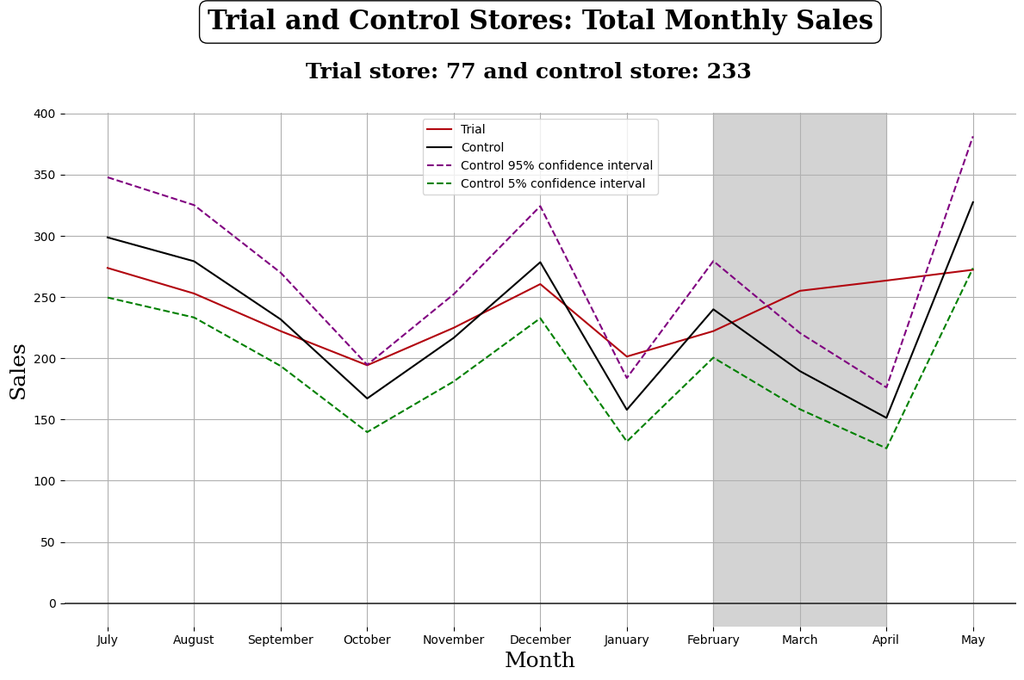

```
  YEARMONTH TOT_SALES_77.0 TOT_SALES_233.0 scaled_sales_77.0  \
7   2019-02          222.2           228.7              None
8   2019-03          255.1           180.6              None
9   2019-04          263.5           144.2              None

  scaled_sales_233.0 percentage_diff   t_value  is_significant
7         239.992191        0.074137  0.876099           False
8         189.517227        0.346052  4.089422            True
9         151.319956        0.741343  8.760729            True
```

```python
print(significance_check(77,233))
```

The results show that the trial in store 77 is significantly different to its control store in the trial period as the trial store performance lies outside the 5% to 95% confidence interval of the control store in two of the three trial months.

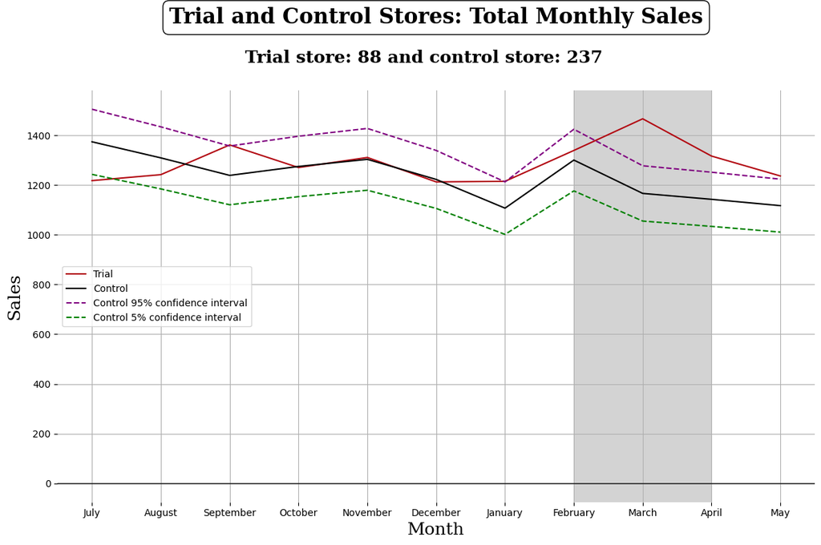

```
  YEARMONTH TOT_SALES_88.0 TOT_SALES_237.0 scaled_sales_88.0  \
7   2019-02         1339.6          1313.0              None
8   2019-03         1467.0          1177.6              None
9   2019-04         1317.0          1153.6              None

  scaled_sales_237.0 percentage_diff   t_value  is_significant
7        1300.879003        0.029765  0.606487           False
8        1166.728952        0.257361   5.24391            True
9        1142.950509        0.152281  3.102824            True
```

```python
print(significance_check(88,237))
```

The results show that the trial in store 88 is significantly different to its control store in the trial period as the trial store performance lies outside the 5% to 95% confidence interval of the control store in two of the three trial months.

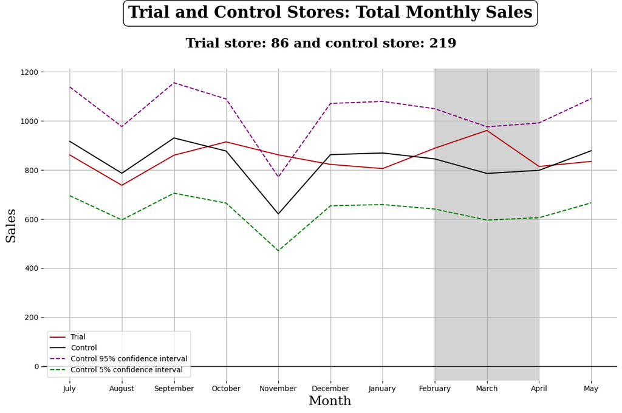

```
  YEARMONTH TOT_SALES_86.0 TOT_SALES_219.0 scaled_sales_86.0  \
7   2019-02          888.8           787.2              None
8   2019-03          961.2           732.0              None
9   2019-04          814.4           743.8              None

  scaled_sales_219.0 percentage_diff   t_value  is_significant
7         845.248739        0.051525  0.414062           False
8         785.978249        0.222935  1.791539           False
9          798.64839        0.019723  0.158496           False
```

```python
print(significance_check(86,219))
```

The results show that the trial in store 86 is not significantly different to its control store in the trial period as the trial store performance lies inside the 5% to 95% confidence interval of the control store in all three trial months.

## Let's Find Out Why?

### No. of Monthly Customers

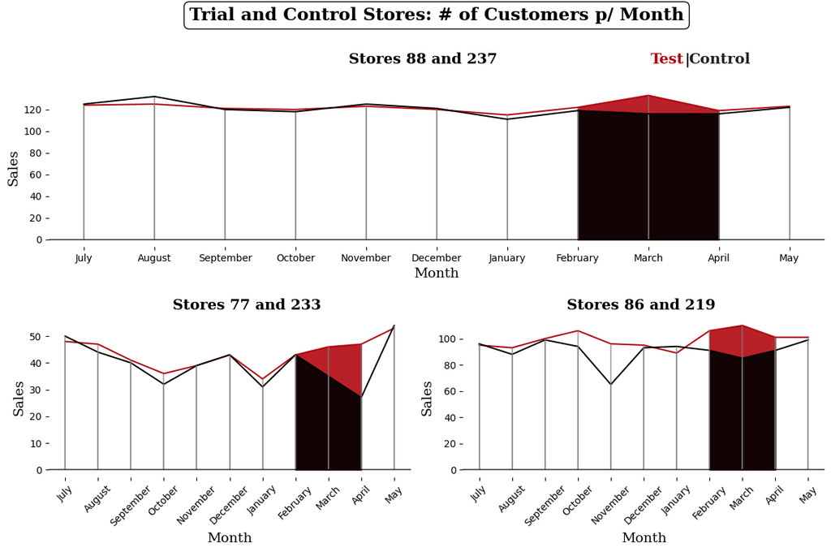

```python
color = ["#b20710", "#221f1f"]

fig, ax = plt.subplots(2, 2, figsize=(12, 8))

# Plot
ax[1,0].plot(monthly_customers.index.month_name(), monthly_customers.loc[:,77], color=color[0], label='Test Store')
# Fill only between start and end date
ax[1,0].fill_between(monthly_customers.index.month_name(), monthly_customers.loc[:,77], 0, where=(monthly_customers.index>'2019-01-31') & (monthly_customers.index<='2019-04-30'), color=color[0], alpha=0.9)
ax[1,0].plot(monthly_customers.index.month_name(), monthly_customers.loc[:,233], color='black', label='Control Store')
ax[1,0].fill_between(monthly_customers.index.month_name(), monthly_customers.loc[:,233], 0, where=(monthly_customers.index>'2019-01-31') & (monthly_customers.index<='2019-04-30'), color='black', alpha=0.9)
# Axis labels
ax[1,0].set_xlabel('Month', fontsize=14, fontfamily='serif')
ax[1,0].set_ylabel('Sales', fontsize=14, fontfamily='serif')
# Fix x-ticks
ax[1,0].set_xticks(monthly_customers.index.month_name())
ax[1,0].set_xticklabels(monthly_customers.index.month_name(), rotation=45)

for date in monthly_customers.index:
    ax[1,0].vlines(x=date.month_name(), ymin=0, ymax=monthly_customers.loc[date, 77], colors='grey', alpha=0.6)
    ax[1,0].vlines(x=date.month_name(), ymin=0, ymax=monthly_customers.loc[date, 233], colors='grey', alpha=0.6)


# Plot
ax[1,1].plot(monthly_customers.index.month_name(), monthly_customers.loc[:,86], color=color[0], label='Test Store')
ax[1,1].fill_between(monthly_customers.index.month_name(), monthly_customers.loc[:,86], 0, where=(monthly_customers.index>'2019-01-31') & (monthly_customers.index<='2019-04-30'), color=color[0], alpha=0.9)
ax[1,1].plot(monthly_customers.index.month_name(), monthly_customers.loc[:,219], color='black', label='Control Store')
ax[1,1].fill_between(monthly_customers.index.month_name(), monthly_customers.loc[:,219], 0, where=(monthly_customers.index>'2019-01-31') & (monthly_customers.index<='2019-04-30'), color='black', alpha=0.9)
# Axis labels
ax[1,1].set_xlabel('Month', fontsize=14, fontfamily='serif')
ax[1,1].set_ylabel('Sales', fontsize=14, fontfamily='serif')
# Fix x-ticks
ax[1,1].set_xticks(monthly_customers.index.month_name())
ax[1,1].set_xticklabels(monthly_customers.index.month_name(), rotation=45)


# Add gridlines
# for i in range(2):
    # ax[1,i].grid(axis='y', color='gray', alpha=.7)

for date in monthly_customers.index:
    ax[1,1].vlines(x=date.month_name(), ymin=0, ymax=monthly_customers.loc[date, 86], colors='grey', alpha=0.6)
    ax[1,1].vlines(x=date.month_name(), ymin=0, ymax=monthly_customers.loc[date, 219], colors='grey', alpha=0.6)
# Horizontal line on x-axis
for i in range(2):
    ax[1,i].yaxis.tick_left()
    ax[1,i].axhline(y = 0, color = 'black', linewidth = 1.3, alpha = .7)
# Remove spines
for i in range(2):
    for s in ['top', 'right','bottom','left']:
        ax[1,i].spines[s].set_visible(False)




# Remove unnecessary subplots
fig.delaxes(ax[0, 1])  # Remove empty subplot
fig.delaxes(ax[0, 0])  # Remove empty subplot

# Add a big top plot
ax_top = fig.add_subplot(2, 1, 1)
# Plot
ax_top.plot(monthly_customers.index.month_name(), monthly_customers.loc[:,88], color=color[0], label='Test Store')
ax_top.fill_between(monthly_customers.index.month_name(), monthly_customers.loc[:,88], 0, where=(monthly_customers.index>'2019-01-31') & (monthly_customers.index<='2019-04-30'), color=color[0], alpha=0.9)
for date in monthly_customers.index:
    ax_top.vlines(x=date.month_name(), ymin=0, ymax=monthly_customers.loc[date, 88], colors='grey', alpha=0.6)
    ax_top.vlines(x=date.month_name(), ymin=0, ymax=monthly_customers.loc[date, 237], colors='grey', alpha=0.6)
ax_top.plot(monthly_customers.index.month_name(), monthly_customers.loc[:,237], color='black', label='Test Store')
ax_top.fill_between(monthly_customers.index.month_name(), monthly_customers.loc[:,237], 0, where=(monthly_customers.index>'2019-01-31') & (monthly_customers.index<='2019-04-30'), color='black', alpha=0.9)


# Plot title
ax_top.set_title('Trial and Control Stores: # of Customers p/ Month', pad=70, fontsize=18, fontfamily='serif', fontweight='bold',
                 bbox=dict(facecolor='white', edgecolor='black', boxstyle='round,pad=0.3'))
# Axis labels
ax_top.set_xlabel('Month', fontsize=14, fontfamily='serif')
ax_top.set_ylabel('Sales', fontsize=14, fontfamily='serif')
# Fix x-ticks
ax_top.set_xticks(monthly_customers.index.month_name())
ax_top.set_xticklabels(monthly_customers.index.month_name(), rotation=0)
# Add gridlines
# ax_top.grid(axis='y', color='gray', alpha=.7)
# Horizontal line on x-axis
ax_top.axhline(y = 0, color = 'black', linewidth = 1.3, alpha = .7)

# Remove spines
for s in ['top', 'right','bottom','left']:
    ax_top.spines[s].set_visible(False)


# Add titles
fig.text(.42, .88, 'Stores 88 and 237', fontsize=15, fontweight='bold', fontfamily='serif')
fig.text(.21, .44, 'Stores 77 and 233', fontsize=15, fontfamily='serif', fontweight='bold')
fig.text(.68, .44, 'Stores 86 and 219', fontsize=15, fontfamily='serif', fontweight='bold')
fig.text(0.78,0.88,"Test", fontweight="bold", fontfamily='serif', fontsize=15, color='#b20710')
fig.text(0.82,0.88,"|", fontweight="bold", fontfamily='serif', fontsize=15, color='black')
fig.text(0.825,0.88,"Control", fontweight="bold", fontfamily='serif', fontsize=15, color='#221f1f')


plt.tight_layout()
plt.subplots_adjust(hspace=.45)
```

### Average Transactions p/Customer

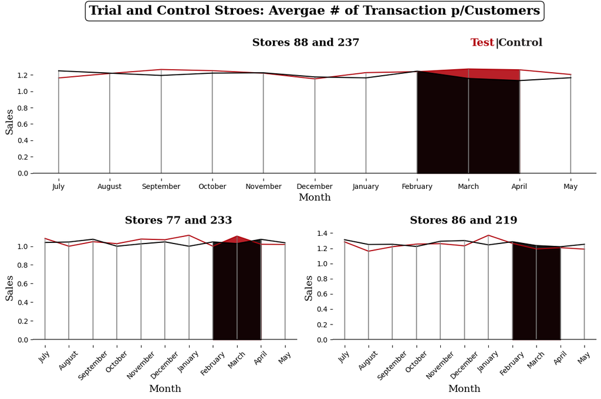

```python
color = ["#b20710", "#221f1f"]

fig, ax = plt.subplots(2, 2, figsize=(12, 8))

# Plot
ax[1,0].plot(avg_transactions_per_customer.index.month_name(), avg_transactions_per_customer.loc[:,77], color=color[0], label='Test Store')
# Fill only between start and end date
ax[1,0].fill_between(avg_transactions_per_customer.index.month_name(), avg_transactions_per_customer.loc[:,77], 0, where=(avg_transactions_per_customer.index>'2019-01-31') & (avg_transactions_per_customer.index<='2019-04-30'), color=color[0], alpha=0.9)
ax[1,0].plot(avg_transactions_per_customer.index.month_name(), avg_transactions_per_customer.loc[:,233], color='black', label='Control Store')
ax[1,0].fill_between(avg_transactions_per_customer.index.month_name(), avg_transactions_per_customer.loc[:,233], 0, where=(avg_transactions_per_customer.index>'2019-01-31') & (avg_transactions_per_customer.index<='2019-04-30'), color='black', alpha=0.9)
# Axis labels
ax[1,0].set_xlabel('Month', fontsize=14, fontfamily='serif')
ax[1,0].set_ylabel('Sales', fontsize=14, fontfamily='serif')
# Fix x-ticks
ax[1,0].set_xticks(avg_transactions_per_customer.index.month_name())
ax[1,0].set_xticklabels(avg_transactions_per_customer.index.month_name(), rotation=45)

for date in avg_transactions_per_customer.index:
    ax[1,0].vlines(x=date.month_name(), ymin=0, ymax=avg_transactions_per_customer.loc[date, 77], colors='grey', alpha=0.6)
    ax[1,0].vlines(x=date.month_name(), ymin=0, ymax=avg_transactions_per_customer.loc[date, 233], colors='grey', alpha=0.6)


# Plot
ax[1,1].plot(avg_transactions_per_customer.index.month_name(), avg_transactions_per_customer.loc[:,86], color=color[0], label='Test Store')
ax[1,1].fill_between(avg_transactions_per_customer.index.month_name(), avg_transactions_per_customer.loc[:,86], 0, where=(avg_transactions_per_customer.index>'2019-01-31') & (avg_transactions_per_customer.index<='2019-04-30'), color=color[0], alpha=0.9)
ax[1,1].plot(avg_transactions_per_customer.index.month_name(), avg_transactions_per_customer.loc[:,219], color='black', label='Control Store')
ax[1,1].fill_between(avg_transactions_per_customer.index.month_name(), avg_transactions_per_customer.loc[:,219], 0, where=(avg_transactions_per_customer.index>'2019-01-31') & (avg_transactions_per_customer.index<='2019-04-30'), color='black', alpha=0.9)
# Axis labels
ax[1,1].set_xlabel('Month', fontsize=14, fontfamily='serif')
ax[1,1].set_ylabel('Sales', fontsize=14, fontfamily='serif')
# Fix x-ticks
ax[1,1].set_xticks(avg_transactions_per_customer.index.month_name())
ax[1,1].set_xticklabels(avg_transactions_per_customer.index.month_name(), rotation=45)


# Add gridlines
# for i in range(2):
    # ax[1,i].grid(axis='y', color='gray', alpha=.7)

for date in avg_transactions_per_customer.index:
    ax[1,1].vlines(x=date.month_name(), ymin=0, ymax=avg_transactions_per_customer.loc[date, 86], colors='grey', alpha=0.6)
    ax[1,1].vlines(x=date.month_name(), ymin=0, ymax=avg_transactions_per_customer.loc[date, 219], colors='grey', alpha=0.6)
# Horizontal line on x-axis
for i in range(2):
    ax[1,i].yaxis.tick_left()
    ax[1,i].axhline(y = 0, color = 'black', linewidth = 1.3, alpha = .7)
# Remove spines
for i in range(2):
    for s in ['top', 'right','bottom','left']:
        ax[1,i].spines[s].set_visible(False)




# Remove unnecessary subplots
fig.delaxes(ax[0, 1])  # Remove empty subplot
fig.delaxes(ax[0, 0])  # Remove empty subplot

# Add a big top plot
ax_top = fig.add_subplot(2, 1, 1)
# Plot
ax_top.plot(avg_transactions_per_customer.index.month_name(), avg_transactions_per_customer.loc[:,88], color=color[0], label='Test Store')
ax_top.fill_between(avg_transactions_per_customer.index.month_name(), avg_transactions_per_customer.loc[:,88], 0, where=(avg_transactions_per_customer.index>'2019-01-31') & (avg_transactions_per_customer.index<='2019-04-30'), color=color[0], alpha=0.9)
for date in avg_transactions_per_customer.index:
    ax_top.vlines(x=date.month_name(), ymin=0, ymax=avg_transactions_per_customer.loc[date, 88], colors='grey', alpha=0.6)
    ax_top.vlines(x=date.month_name(), ymin=0, ymax=avg_transactions_per_customer.loc[date, 237], colors='grey', alpha=0.6)
ax_top.plot(avg_transactions_per_customer.index.month_name(), avg_transactions_per_customer.loc[:,237], color='black', label='Test Store')
ax_top.fill_between(avg_transactions_per_customer.index.month_name(), avg_transactions_per_customer.loc[:,237], 0, where=(avg_transactions_per_customer.index>'2019-01-31') & (avg_transactions_per_customer.index<='2019-04-30'), color='black', alpha=0.9)


# Plot title
ax_top.set_title('Trial and Control Stroes: Avergae # of Transaction p/Customers', pad=70, fontsize=18, fontfamily='serif', fontweight='bold',
                 bbox=dict(facecolor='white', edgecolor='black', boxstyle='round,pad=0.3'))
# Axis labels
ax_top.set_xlabel('Month', fontsize=14, fontfamily='serif')
ax_top.set_ylabel('Sales', fontsize=14, fontfamily='serif')
# Fix x-ticks
ax_top.set_xticks(avg_transactions_per_customer.index.month_name())
ax_top.set_xticklabels(avg_transactions_per_customer.index.month_name(), rotation=0)
# Add gridlines
# ax_top.grid(axis='y', color='gray', alpha=.7)
# Horizontal line on x-axis
ax_top.axhline(y = 0, color = 'black', linewidth = 1.3, alpha = .7)

# Remove spines
for s in ['top', 'right','bottom','left']:
    ax_top.spines[s].set_visible(False)


# Add titles
fig.text(.42, .88, 'Stores 88 and 237', fontsize=15, fontweight='bold', fontfamily='serif')
fig.text(.21, .44, 'Stores 77 and 233', fontsize=15, fontfamily='serif', fontweight='bold')
fig.text(.68, .44, 'Stores 86 and 219', fontsize=15, fontfamily='serif', fontweight='bold')
fig.text(0.78,0.88,"Test", fontweight="bold", fontfamily='serif', fontsize=15, color='#b20710')
fig.text(0.82,0.88,"|", fontweight="bold", fontfamily='serif', fontsize=15, color='black')
fig.text(0.825,0.88,"Control", fontweight="bold", fontfamily='serif', fontsize=15, color='#221f1f')


plt.tight_layout()
plt.subplots_adjust(hspace=.45)
```

### Significance of # of Customers.

```python
def significance_check_customers(trial_store, control_store, pre_trial_cutoff = '2019-02', trial_end = '2019-04-30'):
    # 1. Create YEARMONTH column for grouping
    df['YEARMONTH'] = df['DATE'].dt.to_period('M')

    # 2. Aggregate NO. customers per month per store
    monthly_customers = df.groupby(['YEARMONTH', 'STORE_NBR'])['LYLTY_CARD_NBR'].nunique().reset_index()

    # 3. Compute scaling factor from pre-trial months
    trial_pre_total = monthly_customers[(monthly_customers['STORE_NBR'] == trial_store) &
                                    (monthly_customers['YEARMONTH'] < pre_trial_cutoff)]['LYLTY_CARD_NBR'].sum()

    control_pre_total = monthly_customers[(monthly_customers['STORE_NBR'] == control_store) &
                                    (monthly_customers['YEARMONTH'] < pre_trial_cutoff)]['LYLTY_CARD_NBR'].sum()

    scaling_factor = trial_pre_total / control_pre_total

    # 4. Apply scaling factor to control store
    monthly_customers['scaled_customers'] = None
    monthly_customers.loc[monthly_customers['STORE_NBR'] == control_store, 'scaled_customers'] = \
        monthly_customers.loc[monthly_customers['STORE_NBR'] == control_store, 'LYLTY_CARD_NBR'] * scaling_factor

    # 5. Pivot for comparison (use only relevant stores)
    comparison_df = monthly_customers[monthly_customers['STORE_NBR'].isin([trial_store, control_store])]
    pivoted = comparison_df.pivot(index='YEARMONTH', columns='STORE_NBR', values=['LYLTY_CARD_NBR', 'scaled_customers'])

    # 6. Flatten column names
    pivoted.columns = [f"{metric}_{store}" for metric, store in pivoted.columns]
    pivoted = pivoted.reset_index()

    # 7. Calculate percentage difference from pre-trial months
    pivoted['percentage_diff'] = np.abs(pivoted[f'LYLTY_CARD_NBR_{trial_store}.0'] - pivoted[f'scaled_customers_{control_store}.0']) / pivoted[f'scaled_customers_{control_store}.0']

    # 8. Std deviation from pre-trial period
    pre_trial = pivoted[pivoted['YEARMONTH'] < pre_trial_cutoff]
    std_dev = pre_trial['percentage_diff'].std()
    df_degrees = len(pre_trial) - 1

    # 9. Compute t-values during trial period (e.g. Feb–Apr or Mar–Jun)
    trial_period = pivoted[(pivoted['YEARMONTH'] >= pre_trial_cutoff) & (pivoted['YEARMONTH'] <= trial_end)].copy()
    trial_period['t_value'] = trial_period['percentage_diff'] / std_dev
    trial_period

    # 10. Critical value for 95% confidence
    t_critical = stats.t.ppf(0.95, df_degrees)

    # 11. Significance check
    trial_period['is_significant'] = trial_period['t_value'] > t_critical


    ########################################################################################################################################################


    # Now Plot
    start_date = '2018-07-01'
    end_date = '2019-05-31'

    # Filter the trial date
    filtered_df = df[(df['DATE'] >= start_date) & (df['DATE'] <= end_date)]
    # NO. of CUSTOMERS P/MONTH.
    monthly_customers = filtered_df.groupby(['STORE_NBR', pd.Grouper(key='DATE', freq='ME')])['LYLTY_CARD_NBR'].nunique().unstack(fill_value=0)
    monthly_customers = monthly_customers.T

    color = ["#b20710", "#221f1f"]

    fig = plt.figure(figsize=(12, 8))
    ax = plt.gca()

    # Plot
    ax.plot(monthly_customers.index.month_name(), monthly_customers.loc[:,trial_store], color=color[0], label='Trial')
    ax.plot(monthly_customers.index.month_name(), scaling_factor * monthly_customers.loc[:,control_store], color='black', label='Control')
    ax.plot(monthly_customers.index.month_name(), scaling_factor * monthly_customers.loc[:,control_store] + scaling_factor * monthly_customers.loc[:,control_store]* std_dev * t_critical,
            color='purple', linestyle='--', label=r'Control 95% confidence interval')
    ax.plot(monthly_customers.index.month_name(), scaling_factor * monthly_customers.loc[:,control_store] - scaling_factor * monthly_customers.loc[:,control_store] * std_dev * t_critical,
            color='green', linestyle='--', label=r'Control 5% confidence interval')
    ax.axvspan('February', 'April', color='lightgray')

    # Plot title
    ax.set_title('Trial and Control Stores: # of Customers p/Month', pad=70, fontsize=22, fontfamily='serif', fontweight='bold',
                    bbox=dict(facecolor='white', edgecolor='black', boxstyle='round,pad=0.3'))
    # Axis labels
    ax.set_xlabel('Month', fontsize=18, fontfamily='serif')
    ax.set_ylabel('Customers', fontsize=18, fontfamily='serif')
    # Fix x-ticks
    ax.set_xticks(monthly_customers.index.month_name())
    ax.set_xticklabels(monthly_customers.index.month_name(), rotation=0)
    # Horizontal line on x-axis
    ax.axhline(y = 0, color = 'black', linewidth = 1.3, alpha = .7)
    # Gridlines
    ax.grid()
    fig.text(.3, .88, f'Trial store: {trial_store} and control store: {control_store}', fontsize=18, fontweight='bold', fontfamily='serif')

    # Remove spines
    for s in ['top', 'right','bottom','left']:
        ax.spines[s].set_visible(False)

    plt.tight_layout()
    ax.legend(loc='best')
    plt.show()

    return(trial_period)
```

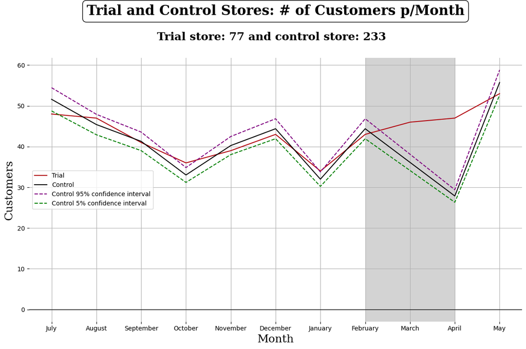

|  | YEARMONTH | LYLTY_CARD_NBR_77.0 | LYLTY_CARD_NBR_233.0 | scaled_customers_77.0 | scaled_customers_233.0 | percentage_diff | t_value | is_significant |
| --- | --- | --- | --- | --- | --- | --- | --- | --- |
| 7 | 2019-02 | 43 | 43 | None | 44.387097 | 0.03125 | 1.099541 | False |
| 8 | 2019-03 | 46 | 35 | None | 36.129032 | 0.273214 | 9.613129 | True |
| 9 | 2019-04 | 47 | 27 | None | 27.870968 | 0.686343 | 24.149175 | True |

```python
significance_check_customers(77,233)
```

It looks like the number of customers is significantly higher in two of the three months. This seems to suggest that the trial had a significant impact on increasing the number of customers in trial store 77 and had an overall positive trial effect.

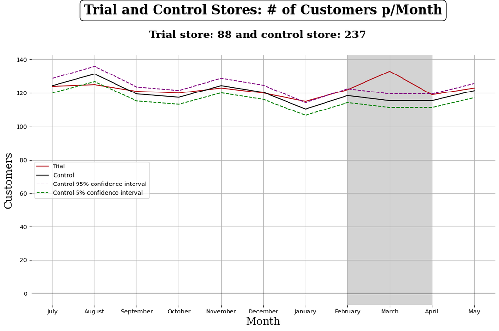

|  | YEARMONTH | LYLTY_CARD_NBR_88.0 | LYLTY_CARD_NBR_237.0 | scaled_customers_88.0 | scaled_customers_237.0 | percentage_diff | t_value | is_significant |
| --- | --- | --- | --- | --- | --- | --- | --- | --- |
| 7 | 2019-02 | 122 | 119 | None | 118.441315 | 0.030046 | 1.677105 | False |
| 8 | 2019-03 | 133 | 116 | None | 115.455399 | 0.15196 | 8.482095 | True |
| 9 | 2019-04 | 119 | 116 | None | 115.455399 | 0.030701 | 1.713669 | False |

```python
significance_check_customers(88,237)
```

It looks like the number of customers is in trial store 88 is not significantly different to its control store as two of the three months lie inside the 5% to 95% confidence interval of the control store. This seems to suggest that the trial had a significant impact on increasing the spending by existing customers.

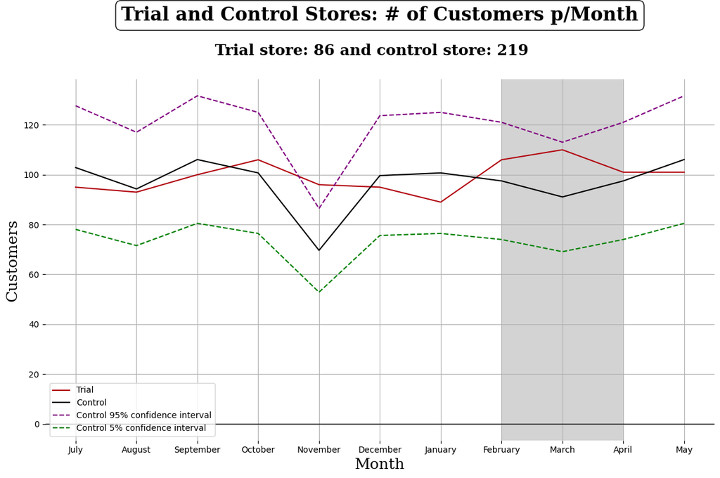

|  | YEARMONTH | LYLTY_CARD_NBR_86.0 | LYLTY_CARD_NBR_219.0 | scaled_customers_86.0 | scaled_customers_219.0 | percentage_diff | t_value | is_significant |
| --- | --- | --- | --- | --- | --- | --- | --- | --- |
| 7 | 2019-02 | 106 | 91 | None | 97.510334 | 0.087064 | 0.701555 | False |
| 8 | 2019-03 | 110 | 85 | None | 91.081081 | 0.207715 | 1.673747 | False |
| 9 | 2019-04 | 101 | 91 | None | 97.510334 | 0.035788 | 0.288373 | False |

```python
significance_check_customers(86,219)
```

The results show that the trial in store 86 is not significantly different to its control store in the trial period as the trial store performance lies inside the 5% to 95% confidence interval of the control store in all three trial months.

### Significance of # of Transactions p/Cusotmer

```python
def significance_check_transactions(trial_store, control_store, pre_trial_cutoff = '2019-02', trial_end = '2019-04-30'):
    # 1. Create YEARMONTH column for grouping
    df['YEARMONTH'] = df['DATE'].dt.to_period('M')

    # 2. Aggregate NO. customers per month per store
    monthly_transactions = df.groupby(['YEARMONTH', 'STORE_NBR']).size().reset_index(name='transactions')
    monthly_customers = df.groupby(['YEARMONTH', 'STORE_NBR'])['LYLTY_CARD_NBR'].nunique().reset_index(name='unique_customers')
    # Merge the two DataFrames on YEARMONTH and STORE_NBR
    merged = pd.merge(monthly_transactions, monthly_customers, on=['YEARMONTH', 'STORE_NBR'])
    avg_transactions_per_customer = merged
    avg_transactions_per_customer['avg_transactions'] = avg_transactions_per_customer['transactions']/avg_transactions_per_customer['unique_customers']

    # 3. Compute scaling factor from pre-trial months
    trial_pre_total = avg_transactions_per_customer[(avg_transactions_per_customer['STORE_NBR'] == trial_store) &
                                    (avg_transactions_per_customer['YEARMONTH'] < pre_trial_cutoff)]['avg_transactions'].sum()

    control_pre_total = avg_transactions_per_customer[(avg_transactions_per_customer['STORE_NBR'] == control_store) &
                                    (avg_transactions_per_customer['YEARMONTH'] < pre_trial_cutoff)]['avg_transactions'].sum()

    scaling_factor = trial_pre_total / control_pre_total

    # 4. Apply scaling factor to control store
    avg_transactions_per_customer['scaled_transactions'] = None
    avg_transactions_per_customer.loc[avg_transactions_per_customer['STORE_NBR'] == control_store, 'scaled_transactions'] = \
        avg_transactions_per_customer.loc[avg_transactions_per_customer['STORE_NBR'] == control_store, 'avg_transactions'] * scaling_factor

    # 5. Pivot for comparison (use only relevant stores)
    comparison_df = avg_transactions_per_customer[avg_transactions_per_customer['STORE_NBR'].isin([trial_store, control_store])]
    pivoted = comparison_df.pivot(index='YEARMONTH', columns='STORE_NBR', values=['avg_transactions', 'scaled_transactions'])

    # 6. Flatten column names
    pivoted.columns = [f"{metric}_{store}" for metric, store in pivoted.columns]
    pivoted = pivoted.reset_index()

    # 7. Calculate percentage difference from pre-trial months
    pivoted['percentage_diff'] = np.abs(pivoted[f'avg_transactions_{trial_store}.0'] - pivoted[f'scaled_transactions_{control_store}.0']) / pivoted[f'scaled_transactions_{control_store}.0']

    # 8. Std deviation from pre-trial period
    pre_trial = pivoted[pivoted['YEARMONTH'] < pre_trial_cutoff]
    std_dev = pre_trial['percentage_diff'].std()
    df_degrees = len(pre_trial) - 1

    # 9. Compute t-values during trial period (e.g. Feb–Apr or Mar–Jun)
    trial_period = pivoted[(pivoted['YEARMONTH'] >= pre_trial_cutoff) & (pivoted['YEARMONTH'] <= trial_end)].copy()
    trial_period['t_value'] = trial_period['percentage_diff'] / std_dev
    trial_period

    # 10. Critical value for 95% confidence
    t_critical = stats.t.ppf(0.95, df_degrees)

    # 11. Significance check
    trial_period['is_significant'] = trial_period['t_value'] > t_critical


    # ########################################################################################################################################################


    # Now Plot
    start_date = '2018-07-01'
    end_date = '2019-05-31'

    # Filter the trial date
    filtered_df = df[(df['DATE'] >= start_date) & (df['DATE'] <= end_date)]
    # Average number of transactions per customer per month.
    monthly_transactions = filtered_df.groupby(['STORE_NBR', pd.Grouper(key='DATE', freq='ME')]).size().unstack(fill_value=0)  # Total transactions (rows) per store per month
    monthly_customers = filtered_df.groupby(['STORE_NBR', pd.Grouper(key='DATE', freq='ME')])['LYLTY_CARD_NBR'].nunique().unstack(fill_value=0)  # Number of unique customers per store per month
    avg_transactions_per_customer = monthly_transactions / monthly_customers  # Calculate the average number of transactions per customer per month
    avg_transactions_per_customer = avg_transactions_per_customer.T

    color = ["#b20710", "#221f1f"]

    fig = plt.figure(figsize=(12, 8))
    ax = plt.gca()

    # Plot
    ax.plot(avg_transactions_per_customer.index.month_name(), avg_transactions_per_customer.loc[:,trial_store], color=color[0], label='Trial')
    ax.plot(avg_transactions_per_customer.index.month_name(), scaling_factor * avg_transactions_per_customer.loc[:,control_store], color='black', label='Control')
    ax.plot(avg_transactions_per_customer.index.month_name(), scaling_factor * avg_transactions_per_customer.loc[:,control_store] + scaling_factor * avg_transactions_per_customer.loc[:,control_store]* std_dev * t_critical,
            color='purple', linestyle='--', label=r'Control 95% confidence interval')
    ax.plot(avg_transactions_per_customer.index.month_name(), scaling_factor * avg_transactions_per_customer.loc[:,control_store] - scaling_factor * avg_transactions_per_customer.loc[:,control_store] * std_dev * t_critical,
            color='green', linestyle='--', label=r'Control 5% confidence interval')
    ax.axvspan('February', 'April', color='lightgray')

    # Plot title
    ax.set_title('Trial and Control Stores: Avg # of Transactions p/Customer', pad=70, fontsize=22, fontfamily='serif', fontweight='bold',
                    bbox=dict(facecolor='white', edgecolor='black', boxstyle='round,pad=0.3'))
    # Axis labels
    ax.set_xlabel('Month', fontsize=18, fontfamily='serif')
    ax.set_ylabel('Customers', fontsize=18, fontfamily='serif')
    # Fix x-ticks
    ax.set_xticks(avg_transactions_per_customer.index.month_name())
    ax.set_xticklabels(avg_transactions_per_customer.index.month_name(), rotation=0)
    # Horizontal line on x-axis
    ax.axhline(y = 0, color = 'black', linewidth = 1.3, alpha = .7)
    # Gridlines
    ax.grid()
    fig.text(.3, .88, f'Trial store: {trial_store} and control store: {control_store}', fontsize=18, fontweight='bold', fontfamily='serif')

    # Remove spines
    for s in ['top', 'right','bottom','left']:
        ax.spines[s].set_visible(False)

    plt.tight_layout()
    ax.legend(loc='best')
    plt.show()

    return(trial_period)
```

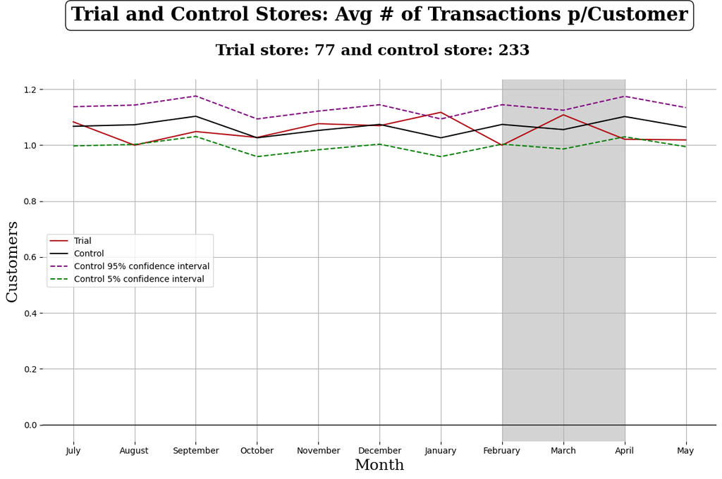

|  | YEARMONTH | avg_transactions_77.0 | avg_transactions_233.0 | scaled_transactions_77.0 | scaled_transactions_233.0 | percentage_diff | t_value | is_significant |
| --- | --- | --- | --- | --- | --- | --- | --- | --- |
| 7 | 2019-02 | 1.0 | 1.046512 | None | 1.074238 | 0.069108 | 2.045447 | True |
| 8 | 2019-03 | 1.108696 | 1.028571 | None | 1.055823 | 0.050078 | 1.482196 | False |
| 9 | 2019-04 | 1.021277 | 1.074074 | None | 1.102531 | 0.073698 | 2.181308 | True |

```python
significance_check_transactions(77,233)
```

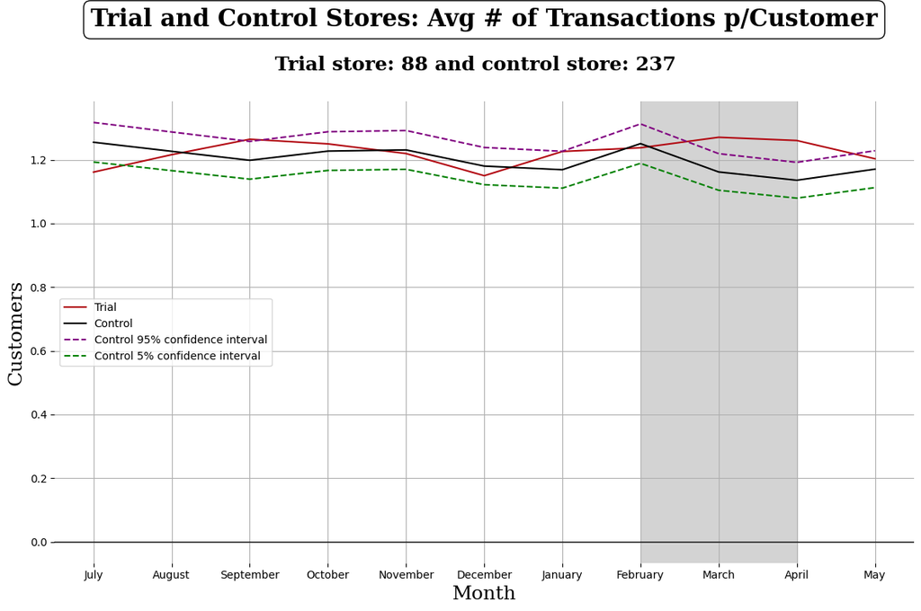

|  | YEARMONTH | avg_transactions_88.0 | avg_transactions_237.0 | scaled_transactions_88.0 | scaled_transactions_237.0 | percentage_diff | t_value | is_significant |
| --- | --- | --- | --- | --- | --- | --- | --- | --- |
| 7 | 2019-02 | 1.237705 | 1.243697 | None | 1.250761 | 0.010439 | 0.409866 | False |
| 8 | 2019-03 | 1.270677 | 1.155172 | None | 1.161734 | 0.093776 | 3.682007 | True |
| 9 | 2019-04 | 1.260504 | 1.12931 | None | 1.135725 | 0.109868 | 4.313818 | True |

```python
significance_check_transactions(88,237)
```

As we had suggested earlier in the # of custoemrs p/Month, it seems the trial run was successful in getting existing customers to make more transactions. This hypothesis is confirmed here as we see the number of transactions p/customer is significantly higher in two of the three months. This suggests that the trial had a significant impact on increasing the number of transactions p/customers in trial store 88 and had an overall positive trial effect.

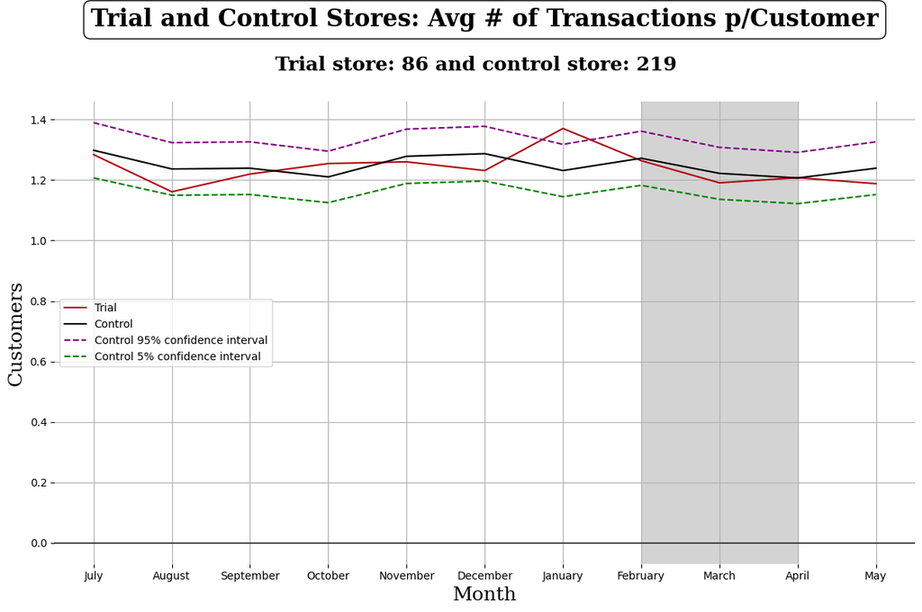

|  | YEARMONTH | avg_transactions_86.0 | avg_transactions_219.0 | scaled_transactions_86.0 | scaled_transactions_219.0 | percentage_diff | t_value | is_significant |
| --- | --- | --- | --- | --- | --- | --- | --- | --- |
| 7 | 2019-02 | 1.264151 | 1.285714 | None | 1.272172 | 0.006305 | 0.174215 | False |
| 8 | 2019-03 | 1.190909 | 1.235294 | None | 1.222283 | 0.025668 | 0.709225 | False |
| 9 | 2019-04 | 1.207921 | 1.21978 | None | 1.206933 | 0.000819 | 0.022621 | False |

```python
significance_check_transactions(86,219)
```

The results show that the trial in store 86 is not significantly different to its control store in the trial period as the trial store performance lies inside the 5% to 95% confidence interval of the control store in all three trial months.

# Conclusion

We’ve found control stores 233, 219, 237 for trial stores 77, 86 and 88 respectively.

The results for trial stores 77 and 88 during the trial period show a significant difference in at least two of the three trial months but this is not the case for trial store 86.

We can check with the client if the implementation of the trial was different in trial store 86.

Overall, the trial shows a significant increase in sales. Now that we have finished our analysis, we can prepare our presentation to the Category Manager.